# **Music Recommendation System**

## **Problem Definition**

### **The Context:**

Recommendations drive modern music streaming services. Users expect passive discovery, where new songs and fresh artists surface effortlessly. Behind this experience lies a finely tuned system. Popularity and trends shape a fair amount of listening behavior, defining what listeners engage with on a large scale. At its essence, music is a shared cultural experience—a soundtrack to moments that unite us. At the same time, music is also deeply personal. We seek music out as a form of self-reflection and self-understanding. A song that just gets us is always just a click away. We might lean toward a favorite genre, but when our hearts break, we instinctively turn to our favorite love song. When we celebrate, we need an anthem.

Achieving this means leveraging both **collaborative filtering** (to surface widely liked content) and **content-based filtering** (to uncover hidden gems tailored to the individual). This project applies these concepts to explore how machine learning can bridge the gap between mass appeal and personal resonance.

### **The objective:**

The goal of this project is to build a **data-driven music recommendation system** that suggests relevant songs based on **user interaction data and text-based similarity**. By leveraging **collaborative filtering (CF) models and content-based filtering**, the model should be able to:

- **Predict songs that a user is likely to enjoy** by analyzing past play counts and patterns in user behavior.
- **Surface songs based on textual similarity** while recognizing the limitations of available metadata (title, artist, release, and year).

### **The key questions:**

- **How do users interact with songs?**
- **What recommendation approach performs best with the data we have?**
- **How do we evaluate recommendation effectiveness?**
- **Can we leverage feature engineering to improve recommendations?**

### **The problem formulation**:

We will use a dataset containing 1,000,000 unique songs and 2,000,000 user-song play interactions to build our system. By analyzing listening behavior, play counts, and song features, the model will predict songs a user might enjoy and suggest them accordingly. The goal is to improve user engagement by presenting relevant and diverse recommendations while handling data challenges such as missing values, duplicate interactions, and data sparsity.

## **Data Dictionary**

The core data is the Taste Profile Subset released by the Echo Nest as part of the Million Song Dataset. There are two files in this dataset. The first file contains the details about the song id, titles, release, artist name, and the year of release. The second file contains the user id, song id, and the play count of users.

**song_data**

- song_id - A unique id given to every song
- title - Title of the song
- Release - Name of the released album
- Artist_name - Name of the artist
- year - Year of release

**count_data**

- user _id - A unique id given to the user
- song_id - A unique id given to the song
- play_count - Number of times the song was played

## **Data Source**

http://millionsongdataset.com/

### **Importing Libraries and the Dataset**

```python
# Mounting the drive
from google.colab import drive
drive.mount('/content/drive')
```

```python
# Install Surprise since it's not pre-installed in this distribution
!pip install surprise
```

```python
# --------------------------------------------
# Standard Libraries
# --------------------------------------------
import json
import warnings
import random
import re  # Regular expressions
from collections import Counter, defaultdict
from IPython.display import display, Markdown

# --------------------------------------------
# Data Processing
# --------------------------------------------
import numpy as np
import pandas as pd
from sklearn.preprocessing import LabelEncoder, StandardScaler  # Encoding & Scaling
from sklearn.impute import KNNImputer  # kNN imputation

# --------------------------------------------
# Visualization
# --------------------------------------------
import matplotlib.pyplot as plt
import seaborn as sns

# --------------------------------------------
# Recommendation Systems (Surprise Library)
# --------------------------------------------
from surprise import accuracy, CoClustering, PredictionImpossible
from surprise.dataset import Dataset
from surprise.reader import Reader
from surprise.prediction_algorithms.knns import KNNBasic, KNNBaseline
from surprise.prediction_algorithms.matrix_factorization import SVD
from surprise.model_selection import train_test_split, GridSearchCV, KFold

# Alias sklearn train_test_split to avoid conflict with Surprise
from sklearn.model_selection import train_test_split as sk_train_test_split

# --------------------------------------------
# Clustering & Similarity
# --------------------------------------------
from sklearn.cluster import KMeans  # k-Means clustering
from sklearn.metrics import silhouette_score  # Clustering evaluation
from sklearn.metrics.pairwise import cosine_similarity  # Similarity measurement

# --------------------------------------------
# Natural Language Processing (NLP)
# --------------------------------------------
from sklearn.feature_extraction.text import CountVectorizer, TfidfVectorizer
```

```python
# Ignore warning level output
warnings.filterwarnings('ignore')
```

### **Load the dataset**

```python
# Load datasets
song_df = pd.read_csv("/content/drive/MyDrive/Capstone/song_data.csv")
count_df = pd.read_csv("/content/drive/MyDrive/Capstone/count_data.csv")
```

### **Understand the data and view a few observations**

```python
display(count_df.head())
```

|  | Unnamed: 0 | user_id | song_id | play_count |
| --- | --- | --- | --- | --- |
| 0 | 0 | b80344d063b5ccb3212f76538f3d9e43d87dca9e | SOAKIMP12A8C130995 | 1 |
| 1 | 1 | b80344d063b5ccb3212f76538f3d9e43d87dca9e | SOBBMDR12A8C13253B | 2 |
| 2 | 2 | b80344d063b5ccb3212f76538f3d9e43d87dca9e | SOBXHDL12A81C204C0 | 1 |
| 3 | 3 | b80344d063b5ccb3212f76538f3d9e43d87dca9e | SOBYHAJ12A6701BF1D | 1 |
| 4 | 4 | b80344d063b5ccb3212f76538f3d9e43d87dca9e | SODACBL12A8C13C273 | 1 |

```python
display(song_df.head())
```

|  | song_id | title | release | artist_name | year |
| --- | --- | --- | --- | --- | --- |
| 0 | SOQMMHC12AB0180CB8 | Silent Night | Monster Ballads X-Mas | Faster Pussy cat | 2003 |
| 1 | SOVFVAK12A8C1350D9 | Tanssi vaan | Karkuteillä | Karkkiautomaatti | 1995 |
| 2 | SOGTUKN12AB017F4F1 | No One Could Ever | Butter | Hudson Mohawke | 2006 |
| 3 | SOBNYVR12A8C13558C | Si Vos Querés | De Culo | Yerba Brava | 2003 |
| 4 | SOHSBXH12A8C13B0DF | Tangle Of Aspens | Rene Ablaze Presents Winter Sessions | Der Mystic | 0 |

### **Check the data types and missing values for each column**

```python
# Display info of count_df
display(Markdown("### Count Data"))
count_df.info()

# Display a visual separator
display(Markdown("---"))

# Display info of song_df
display(Markdown("### Song Data"))
song_df.info()
```

Count Data

```
<class 'pandas.core.frame.DataFrame'>
RangeIndex: 2000000 entries, 0 to 1999999
Data columns (total 4 columns):
 #   Column      Dtype
---  ------      -----
 0   Unnamed: 0  int64
 1   user_id     object
 2   song_id     object
 3   play_count  int64
dtypes: int64(2), object(2)
memory usage: 61.0+ MB
```

Song Data

```
<class 'pandas.core.frame.DataFrame'>
RangeIndex: 1000000 entries, 0 to 999999
Data columns (total 5 columns):
 #   Column       Non-Null Count    Dtype
---  ------       --------------    -----
 0   song_id      1000000 non-null  object
 1   title        999983 non-null   object
 2   release      999993 non-null   object
 3   artist_name  1000000 non-null  object
 4   year         1000000 non-null  int64
dtypes: int64(1), object(4)
memory usage: 38.1+ MB
```

#### **Observations**

- **Count Data** contains **2M records**
  - `Unnamed: 0` duplicates the index and should be dropped.
- **Song Metadata** contains **1M records**
  - `song_id` is primary key to join with count_data.
  - `year` has an invalid value (0).

**Values are Missing in Song Metadata**

- `title` - 17 missing
  - Fill with "Unknown Title".
- `release` - 7 missing
  - Fill with "Unknown Release".
- `year` - 0 indicates hidden missing values
  - Collaborative based model won't use this feature.
  - If leveraged in Content based system, it could be worth imputing.

**Missing Values Treatment**:

```python
# Fill missing values in 'title' column with "Unknown Title"
song_df["title"] = song_df["title"].fillna("Unknown Title")
# Fill missing values in 'release' column with "Unknown Release"
song_df["release"] = song_df["release"].fillna("Unknown Release")
```

**Merge and Finish Cleaning:**

```python
# First, merge count_df and song_df on "song_id", dropping duplicates from song_df
count_df = count_df.merge(song_df.drop_duplicates(subset="song_id"), on="song_id", how="left")

# Drop the column 'Unnamed: 0'
df = count_df.drop(columns=["Unnamed: 0"], errors="ignore")

# Verify the columns to confirm 'Unnamed: 0' is gone
display(df.head())
```

|  | user_id | song_id | play_count | title | release | artist_name | year |
| --- | --- | --- | --- | --- | --- | --- | --- |
| 0 | b80344d063b5ccb3212f76538f3d9e43d87dca9e | SOAKIMP12A8C130995 | 1 | The Cove | Thicker Than Water | Jack Johnson | 0 |
| 1 | b80344d063b5ccb3212f76538f3d9e43d87dca9e | SOBBMDR12A8C13253B | 2 | Entre Dos Aguas | Flamenco Para Niños | Paco De Lucia | 1976 |
| 2 | b80344d063b5ccb3212f76538f3d9e43d87dca9e | SOBXHDL12A81C204C0 | 1 | Stronger | Graduation | Kanye West | 2007 |
| 3 | b80344d063b5ccb3212f76538f3d9e43d87dca9e | SOBYHAJ12A6701BF1D | 1 | Constellations | In Between Dreams | Jack Johnson | 2005 |
| 4 | b80344d063b5ccb3212f76538f3d9e43d87dca9e | SODACBL12A8C13C273 | 1 | Learn To Fly | There Is Nothing Left To Lose | Foo Fighters | 1999 |

#### **Observations**:

- We have the foundaitonal data merged and cleansed.
- We should continue to prepare this data for model building.

**Think About It:** As the user_id and song_id are encrypted. Can they be encoded to numeric features?

```python
# Apply label encoding for "user_id" and "song_id"

# Initialize label encoders, one for users, one for songs
user_encoder = LabelEncoder()
song_encoder = LabelEncoder()

# Apply label encoding
df["user_id"] = user_encoder.fit_transform(df["user_id"])
df["song_id"] = song_encoder.fit_transform(df["song_id"])

# Verify the transformation
display(df.head())
```

|  | user_id | song_id | play_count | title | release | artist_name | year |
| --- | --- | --- | --- | --- | --- | --- | --- |
| 0 | 54961 | 153 | 1 | The Cove | Thicker Than Water | Jack Johnson | 0 |
| 1 | 54961 | 413 | 2 | Entre Dos Aguas | Flamenco Para Niños | Paco De Lucia | 1976 |
| 2 | 54961 | 736 | 1 | Stronger | Graduation | Kanye West | 2007 |
| 3 | 54961 | 750 | 1 | Constellations | In Between Dreams | Jack Johnson | 2005 |
| 4 | 54961 | 1188 | 1 | Learn To Fly | There Is Nothing Left To Lose | Foo Fighters | 1999 |

**Think About It:** As the data also contains users who have listened to very few songs and vice versa, is it required to filter the data so that it contains users who have listened to a good count of songs and vice versa?

A dataset of size 2000000 rows x 7 columns can be quite large and may require a lot of computing resources to process. This can lead to long processing times and can make it difficult to train and evaluate your model efficiently. In order to address this issue, it may be necessary to trim down your dataset to a more manageable size.

```python
# Preserve a copy of the unfiltered dataset for content-based filtering
df_content = df.copy()  # This dataset will remain untouched for content-based recommendations

# === Apply CF-specific filtering ===

# Step 1: Filter users who have listened to at least 90 songs
user_counts = df["user_id"].value_counts()
users_to_keep = user_counts[user_counts >= 90].index
df = df[df["user_id"].isin(users_to_keep)]

# Step 2: Filter songs listened to by at least 120 unique users
song_counts = df["song_id"].value_counts()
songs_to_keep = song_counts[song_counts >= 120].index
df_final = df[df["song_id"].isin(songs_to_keep)]

# Step 3: Keep only records where play_count is <= 5
df_final = df_final[df_final["play_count"] <= 5]

# Display final shape
print(df_final.shape)  # Should match (117876, 7)
```

```
(117876, 7)
```

Out of all the songs available, songs with play_count less than or equal to 5 are in almost 90% abundance. So for building the recommendation system let us consider only those songs.

#### **Observations**

- We have reduced our dtaset from **2M to 117,876**.
- Strong for **collaborative filtering** → Ensures meaningful user-song interactions.
- Potential loss of niche songs → Might reduce long-tail recommendations.
- Content-based models remain effective → As long as song metadata is well-distributed, we can leverage this dataset for content-based. We also have made a copy of the data before filtering for exploratory purposes.

## **Exploratory Data Analysis**

### **Let's check the total number of unique users, songs, artists in the data**

Total number of unique user, songs and artists.

```python
# Display total number of unique user_id
num_users = df_final["user_id"].nunique()

# Display total number of unique song_id
num_songs = df_final["song_id"].nunique()

# Display total number of unique artists
num_artists = df_final["artist_name"].nunique()

# Total number of records
total_rows = len(df_final)  # This is your dataset size

# Compute percentages
percent_users = (num_users / total_rows) * 100
percent_songs = (num_songs / total_rows) * 100
percent_artists = (num_artists / total_rows) * 100

# Display results
print(f"Total Unique Users: {num_users} ({percent_users:.2f}%)")
print(f"Total Unique Songs: {num_songs} ({percent_songs:.2f}%)")
print(f"Total Unique Artists: {num_artists} ({percent_artists:.2f}%)")
```

```
Total Unique Users: 3155 (2.68%)
Total Unique Songs: 563 (0.48%)
Total Unique Artists: 232 (0.20%)
```

**Observations:**

### **Let's find out about the most interacted songs and interacted users**

Most interacted songs

```python
# Get top 10 most interacted songs
most_interacted_songs = df_final["song_id"].value_counts().head(10).reset_index()
most_interacted_songs.columns = ["song_id", "interactions"]

# Aggregate song-level statistics
song_stats = df_final.groupby("song_id").agg(
    total_play_count=("play_count", "sum"),   # Total play count across users
    avg_play_count=("play_count", "mean"),    # Average play count per user
    unique_users=("user_id", "nunique")       # Unique users who played the song
).reset_index()

# Merge with song metadata
most_interacted_songs_full = most_interacted_songs.merge(song_stats, on="song_id", how="left") \
    .merge(df_final[["song_id", "title", "artist_name", "release"]].drop_duplicates(), on="song_id", how="left")

# Print properly formatted
print("Top 10 Most Interacted Songs (with Summary Stats)")
display(most_interacted_songs_full)
```

```
Top 10 Most Interacted Songs (with Summary Stats)
```

|  | song_id | interactions | total_play_count | avg_play_count | unique_users | title | artist_name | release |
| --- | --- | --- | --- | --- | --- | --- | --- | --- |
| 0 | 8582 | 751 | 1463 | 1.948069 | 751 | Use Somebody | Kings Of Leon | Use Somebody |
| 1 | 352 | 748 | 1634 | 2.184492 | 748 | Dog Days Are Over (Radio Edit) | Florence + The Machine | Now That's What I Call Music! 75 |
| 2 | 2220 | 713 | 1583 | 2.220196 | 713 | Sehr kosmisch | Harmonia | Musik von Harmonia |
| 3 | 1118 | 662 | 1203 | 1.817221 | 662 | Clocks | Coldplay | A Rush Of Blood To The Head |
| 4 | 4152 | 652 | 1259 | 1.930982 | 652 | The Scientist | Coldplay | The Scientist |
| 5 | 5531 | 618 | 1427 | 2.309061 | 618 | Secrets | OneRepublic | Waking Up |
| 6 | 4448 | 609 | 1291 | 2.119869 | 609 | Fireflies | Charttraxx Karaoke | Karaoke Monthly Vol. 2 (January 2010) |
| 7 | 6189 | 606 | 1067 | 1.760726 | 606 | Creep (Explicit) | Radiohead | Pablo Honey |
| 8 | 6293 | 583 | 1025 | 1.758148 | 583 | Yellow | Coldplay | Yellow |
| 9 | 1334 | 570 | 1208 | 2.119298 | 570 | Hey_ Soul Sister | Train | Save Me_ San Francisco |

Most interacted users

```python
# Get top 10 most active users
most_interacted_users = df_final["user_id"].value_counts().head(10).reset_index()
most_interacted_users.columns = ["user_id", "total_interactions"]

# Aggregate user-level statistics
user_stats = df_final.groupby("user_id").agg(
    total_play_count=("play_count", "sum"),         # Total play count across all songs
    avg_play_count=("play_count", "mean"),          # Average play count per song
    unique_songs=("song_id", "nunique"),            # Unique songs the user has listened to
    top_song_id=("song_id", lambda x: x.value_counts().idxmax())  # Most played song (by ID)
).reset_index()

# Merge with song metadata to get the song title
user_stats = user_stats.merge(df_final[["song_id", "title"]].drop_duplicates(),
                              left_on="top_song_id", right_on="song_id", how="left")

# Rename the column for clarity and drop redundant song_id column
user_stats.rename(columns={"title": "top_song"}, inplace=True)
user_stats.drop(columns=["song_id"], inplace=True)

# Merge with top users
most_interacted_users_full = most_interacted_users.merge(user_stats, on="user_id", how="left")

# Print properly formatted
print("Top 10 Most Active Users (Summarized Stats)")
display(most_interacted_users_full)
```

```
Top 10 Most Active Users (Summarized Stats)
```

|  | user_id | total_interactions | total_play_count | avg_play_count | unique_songs | top_song_id | top_song |
| --- | --- | --- | --- | --- | --- | --- | --- |
| 0 | 61472 | 243 | 361 | 1.485597 | 243 | 21 | Back Against The Wall |
| 1 | 15733 | 227 | 479 | 2.110132 | 227 | 21 | Back Against The Wall |
| 2 | 37049 | 202 | 377 | 1.866337 | 202 | 21 | Back Against The Wall |
| 3 | 9570 | 184 | 317 | 1.722826 | 184 | 52 | Halo |
| 4 | 23337 | 177 | 399 | 2.254237 | 177 | 21 | Back Against The Wall |
| 5 | 10763 | 176 | 258 | 1.465909 | 176 | 21 | Back Against The Wall |
| 6 | 26616 | 175 | 253 | 1.445714 | 175 | 21 | Back Against The Wall |
| 7 | 9097 | 175 | 240 | 1.371429 | 175 | 21 | Back Against The Wall |
| 8 | 43041 | 174 | 417 | 2.396552 | 174 | 22 | Halo |
| 9 | 65994 | 171 | 243 | 1.421053 | 171 | 21 | Back Against The Wall |

**Observations:**

1. **Highly Skewed Interaction Distribution**
   - The most popular song (*Use Somebody* by Kings of Leon) has **751** interactions, indicating a few songs dominate user engagement.
   - Engagement drops quickly, with the 10th most popular song having **570** interactions*.
2. **Active Users & Engagement Patterns**
   - Most active users have between **170-243 interactions**, with some replaying their favorite songs multiple times.
   - Top users tend to listen to a concentrated set of songs, with *Back Against the Wall* appearing multiple times as their most-played song.
3. **Potential Cold-Start Issues**
   - Less popular songs and infrequent users may struggle to receive recommendations, which could impact diversity.
   - Collaborative filtering may reinforce popularity bias.
4. **Play Count Variability**
   - Some songs have high unique user counts but lower average play counts, indicating they were discovered often but not necessarily replayed.
   - Others, like *Hey, Soul Sister* by Train, have higher average plays per user, suggesting stronger song retention.

Songs released on yearly basis

```python
# Count the number of songs released in a year, use the songs_df
count_songs = song_df.groupby('year').count()['title']
count = pd.DataFrame(count_songs)
count.drop(count.index[0], inplace = True)
count.tail(10)
```

| year | title |
| --- | --- |
| 2002 | 23472 |
| 2003 | 27389 |
| 2004 | 29618 |
| 2005 | 34960 |
| 2006 | 37546 |
| 2007 | 39414 |
| 2008 | 34770 |
| 2009 | 31051 |
| 2010 | 9397 |
| 2011 | 1 |

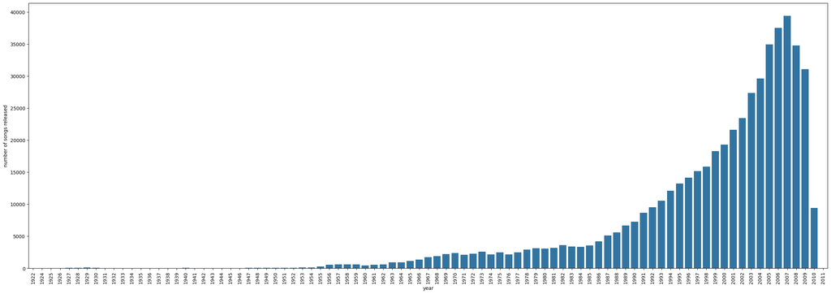

```python
plt.figure(figsize = (30,10))
ax = sns.barplot(x = count.index,
            y = 'title',
            data = count,
            estimator = np.median,)
for item in ax.get_xticklabels(): item.set_rotation(90)
plt.ylabel('number of songs released')
# Show the plot
plt.show()
```

**Observations**

**Think About It:** What other insights can be drawn using exploratory data analysis?

```python
most_played_songs = df_final.groupby("title")["play_count"].sum().reset_index()
most_played_songs = most_played_songs.sort_values(by="play_count", ascending=False).head(10)
print('Most Played Songs')
display(most_played_songs)
```

```
Most Played Songs
```

|  | title | play_count |
| --- | --- | --- |
| 105 | Dog Days Are Over (Radio Edit) | 1634 |
| 391 | Sehr kosmisch | 1583 |
| 510 | Use Somebody | 1463 |
| 390 | Secrets | 1427 |
| 140 | Fireflies | 1291 |
| 473 | The Scientist | 1259 |
| 185 | Hey_ Soul Sister | 1208 |
| 80 | Clocks | 1203 |
| 331 | OMG | 1126 |
| 92 | Creep (Explicit) | 1067 |

```python
artist_popularity = df_final.groupby("artist_name")["play_count"].sum().reset_index()
artist_popularity = artist_popularity.sort_values(by="play_count", ascending=False).head(10)
print('Most Popular Artist')
display(artist_popularity)
```

```
Most Popular Artist
```

|  | artist_name | play_count |
| --- | --- | --- |
| 40 | Coldplay | 9049 |
| 192 | The Killers | 6152 |
| 73 | Florence + The Machine | 5422 |
| 113 | Kings Of Leon | 4855 |
| 103 | Justin Bieber | 3496 |
| 231 | the bird and the bee | 3479 |
| 225 | Vampire Weekend | 3332 |
| 114 | LCD Soundsystem | 3283 |
| 145 | Octopus Project | 2881 |
| 160 | Radiohead | 2753 |

```python
avg_songs_per_user = df_final.groupby("user_id")["song_id"].nunique().mean()
print(f"Average Unique Songs Per User: {avg_songs_per_user:.2f}")
```

```
Average Unique Songs Per User: 37.36
```

Now that we have explored the data, let's apply different algorithms to build recommendation systems.

**Note:** Use the shorter version of the data, i.e., the data after the cutoffs as used in Milestone 1.

## Building various models

### **Popularity-Based Recommendation Systems**

Let's take the count and sum of play counts of the songs and build the popularity recommendation systems based on the sum of play counts.

```python
# Calculate the average play_count per song_id
avg_play_count = df_final.groupby("song_id")["play_count"].mean().reset_index()

# Rename column for clarity
avg_play_count.rename(columns={"play_count": "avg_play_count"}, inplace=True)

# Calculate frequency of each song_id
song_play_frequency = df_final.groupby("song_id")["user_id"].count().reset_index()

# Rename column for clarity
song_play_frequency.rename(columns={"user_id": "play_frequency"}, inplace=True)
```

```python
# Merge the two df together
song_stats = avg_play_count.merge(song_play_frequency, on="song_id")
display(song_stats.head())
```

|  | song_id | avg_play_count | play_frequency |
| --- | --- | --- | --- |
| 0 | 21 | 1.622642 | 265 |
| 1 | 22 | 1.492424 | 132 |
| 2 | 52 | 1.729216 | 421 |
| 3 | 62 | 1.728070 | 114 |
| 4 | 93 | 1.452174 | 115 |

Now, let's create a function to find the top n songs for a recommendation based on the average play count of song. We can also add a threshold for a minimum number of playcounts for a song to be considered for recommendation.

```python
# Build the function to find top n songs
def get_top_n_songs(df, n=10, metric="play_frequency"):
    """
    Returns the top n songs based on a given metric.

    Parameters:
    - df (DataFrame): The DataFrame containing song stats.
    - n (int): The number of top songs to return (default=10).
    - metric (str): The metric to rank songs by. Options:
        - "play_frequency" (default): Most played songs (number of unique user interactions).
        - "avg_play_count": Songs with the highest average play count per user.

    Returns:
    - DataFrame: Top `n` songs ranked by the specified metric.
    """

    if metric not in ["play_frequency", "avg_play_count"]:
        raise ValueError("Invalid metric. Choose 'play_frequency' or 'avg_play_count'.")

    # Sort by the chosen metric in descending order and return top n
    top_songs = df.sort_values(by=metric, ascending=False).head(n)

    return top_songs
```

```python
from IPython.display import display, Markdown

# Create a copy to avoid modifying df_final directly
df_final_copy = df_final.copy()
df_final_copy["song_id"] = df_final_copy["song_id"].astype(str)

# Ensure song_id is a string for merging in song_stats
song_stats["song_id"] = song_stats["song_id"].astype(str)

# Get top 10 most frequently played songs
display(Markdown("### Top 10 Most Frequently Played Songs"))
top_10_frequent = get_top_n_songs(song_stats, n=10, metric="play_frequency")

# Merge with metadata before displaying
top_10_frequent = top_10_frequent.merge(
    df_final_copy[["song_id", "title", "artist_name", "release"]].drop_duplicates(),
    on="song_id",
    how="left"
)

display(top_10_frequent[["song_id", "title", "artist_name", "release", "play_frequency"]])

# Add a visual separator
display(Markdown("---"))

# Get top 10 songs with highest average play count
display(Markdown("### Top 10 Songs with Highest Average Play Count"))
top_10_avg_play = get_top_n_songs(song_stats, n=10, metric="avg_play_count")

# Merge with metadata before displaying
top_10_avg_play = top_10_avg_play.merge(
    df_final_copy[["song_id", "title", "artist_name", "release"]].drop_duplicates(),
    on="song_id",
    how="left"
)

display(top_10_avg_play[["song_id", "title", "artist_name", "release", "avg_play_count"]])
```

Top 10 Most Frequently Played Songs

|  | song_id | title | artist_name | release | play_frequency |
| --- | --- | --- | --- | --- | --- |
| 0 | 8582 | Use Somebody | Kings Of Leon | Use Somebody | 751 |
| 1 | 352 | Dog Days Are Over (Radio Edit) | Florence + The Machine | Now That's What I Call Music! 75 | 748 |
| 2 | 2220 | Sehr kosmisch | Harmonia | Musik von Harmonia | 713 |
| 3 | 1118 | Clocks | Coldplay | A Rush Of Blood To The Head | 662 |
| 4 | 4152 | The Scientist | Coldplay | The Scientist | 652 |
| 5 | 5531 | Secrets | OneRepublic | Waking Up | 618 |
| 6 | 4448 | Fireflies | Charttraxx Karaoke | Karaoke Monthly Vol. 2 (January 2010) | 609 |
| 7 | 6189 | Creep (Explicit) | Radiohead | Pablo Honey | 606 |
| 8 | 6293 | Yellow | Coldplay | Yellow | 583 |
| 9 | 1334 | Hey_ Soul Sister | Train | Save Me_ San Francisco | 570 |

Top 10 Songs with Highest Average Play Count

|  | song_id | title | artist_name | release | avg_play_count |
| --- | --- | --- | --- | --- | --- |
| 0 | 7224 | Victoria (LP Version) | Old 97's | Hit By A Train: The Best Of Old 97's | 3.373832 |
| 1 | 8324 | The Big Gundown | The Prodigy | Invaders Must Die Remixes and Bonus Tracks | 2.625000 |
| 2 | 6450 | Brave The Elements | Colossal | Brave The Elements - EP | 2.578431 |
| 3 | 9942 | Greece 2000 | Three Drives | Greece 2000 | 2.486667 |
| 4 | 5531 | Secrets | OneRepublic | Waking Up | 2.309061 |
| 5 | 5653 | Transparency | White Denim | Workout Holiday | 2.296296 |
| 6 | 8483 | Video Killed The Radio Star | The Buggles | Friends Reunited: Music Of The Year 1979 | 2.235772 |
| 7 | 2220 | Sehr kosmisch | Harmonia | Musik von Harmonia | 2.220196 |
| 8 | 657 | Luvstruck | Southside Spinners | Hard House Anthems | 2.218543 |
| 9 | 614 | You're The One | Dwight Yoakam | If There Was A Way | 2.217158 |

### **User User Similarity-Based Collaborative Filtering**

To build the user-user-similarity-based and subsequent models we will use the "surprise" library.

### Some useful functions

Below is the function to calculate precision@k and recall@k, RMSE, and F1_Score@k to evaluate the model performance.

**Think About It:** Which metric should be used for this problem to compare different models?

Below we are loading the **dataset**, which is a **pandas dataframe**, into a **different format called `surprise.dataset.DatasetAutoFolds`** which is required by this library. To do this we will be **using the classes `Reader` and `Dataset`**

You will also notice here that we read the dataset by providing a scale of ratings. However, as you would know, we do not have ratings data of the songs. In this case, we are going to use play_count as a proxy for ratings with the assumption that the more the user listens to a song, the higher the chance that they like the song

```python
# Check the mean to decide threshold
global_mean = df_final["play_count"].mean()
print(f"Global Mean Play Count: {global_mean:.4f}")
```

```
Global Mean Play Count: 1.7001
```

```python
DEFAULT_K = 30
# Threshold. of 1.8, slightly above the mean
DEFAULT_THRESHOLD = 1.8

# Dictionary to store model evaluation results incrementally
model_comparison_results = {}

def precision_recall_at_k(model, model_name, testset, k=DEFAULT_K, threshold=DEFAULT_THRESHOLD):
    """
    Evaluates a recommendation model and stores results **without any output**.

    Parameters:
    - model (Surprise Model): The trained model to evaluate.
    - model_name (str): Name of the model for storage & reference.
    - k (int): Number of recommendations to consider.
    - threshold (float): Minimum rating considered as "relevant."

    Returns:
    - Dictionary of model evaluation results (RMSE, Precision@K, Recall@K, F1-score).

    Updates:
    - Stores results in `model_comparison_results` to avoid redundant computation.
    """

    # Skip evaluation if already stored
    if model_name in model_comparison_results:
        return model_comparison_results[model_name]

    # Generate evaluation predictions
    predictions = model.test(testset)
    rmse_value = accuracy.rmse(predictions, verbose=False)  # No print output

    # Map evaluation predictions to each user
    user_est_true = defaultdict(list)
    for uid, _, true_r, est, _ in predictions:
        user_est_true[uid].append((est, true_r))

    precisions, recalls = {}, {}

    for uid, user_ratings in user_est_true.items():
        user_ratings.sort(key=lambda x: x[0], reverse=True)

        # Compute precision and recall
        n_rel = sum(true_r >= threshold for _, true_r in user_ratings)
        n_rec_k = sum(est >= threshold for est, _ in user_ratings[:k])
        n_rel_and_rec_k = sum((true_r >= threshold and est >= threshold) for est, true_r in user_ratings[:k])

        precisions[uid] = n_rel_and_rec_k / n_rec_k if n_rec_k != 0 else 0
        recalls[uid] = n_rel_and_rec_k / n_rel if n_rel != 0 else 0

    # Compute averages
    precision_avg = round(sum(precisions.values()) / len(precisions), 3)
    recall_avg = round(sum(recalls.values()) / len(recalls), 3)
    f1_score = round((2 * precision_avg * recall_avg) / (precision_avg + recall_avg), 3) if (precision_avg + recall_avg) > 0 else 0

    # Store results
    model_comparison_results[model_name] = {
        "RMSE": rmse_value,
        "Precision@k": precision_avg,
        "Recall@k": recall_avg,
        "F1-score": f1_score
    }

    return model_comparison_results[model_name]
```

```python
def pretty_print_model_evaluations(model_comparison_results):
    """
    Display model evaluation results as a table.

    Parameters:
    - model_comparison_results (dict): Dictionary storing RMSE, Precision@K, Recall@K, and F1-score.
    """
    model_evaluations_df = pd.DataFrame.from_dict(model_comparison_results, orient='index')
    model_evaluations_df = model_evaluations_df.reset_index().rename(columns={'index': 'Model'})

    # Display as a clear table
    display(model_evaluations_df)
```

```python
# Define the expected rating scale
reader = Reader(rating_scale=(0, 5))

# Selecting required columns
df_surprise = df_final[["user_id", "song_id", "play_count"]]

# Load the data into Surprise format
data = Dataset.load_from_df(df_surprise, reader)

# Splitting into train and test sets (40% test size)
trainset, testset = train_test_split(data, test_size=0.4, random_state=42)
```

```python
# Define global constants
SAMPLE_USER_ONE = 6958
SAMPLE_USER_ONE_SONG_HEARD = 1671
SAMPLE_USER_ONE_SONG_HEARD_PLAY_COUNT = df_final[(df_final["user_id"] == SAMPLE_USER_ONE) &
                             (df_final["song_id"] == SAMPLE_USER_ONE_SONG_HEARD)]["play_count"].values[0]
assert SAMPLE_USER_ONE_SONG_HEARD_PLAY_COUNT == 2  # Actual play count

SAMPLE_USER_ONE_SONG_UNHEARD = 3232
SAMPLE_USER_TWO = 47786
SAMPLE_USER_TWO_SONG_UNHEARD = 2048

# User two was randonly chosen from th last user in the dataset
assert SAMPLE_USER_TWO == df_final["user_id"].iloc[-1]
sample_user_two_songs = df_final[df_final["user_id"] == SAMPLE_USER_TWO]["song_id"].unique()
# User two's unheard song was the first unheard song found
assert SAMPLE_USER_TWO_SONG_UNHEARD == list(set(df_final["song_id"].unique()) - set(sample_user_two_songs))[0]
```

```python
# Dictionary to store predictions
predictions_store = defaultdict(list)

def make_and_store_prediction(model, model_name, user_id, song_id, actual_play_count=None):
    """
    Predicts the play count for a given user and song using the provided model.
    Stores the prediction in a table format, including actual play count if available.
    Also computes and stores prediction error when actual play count is provided.
    """
    pred = model.predict(uid=user_id, iid=song_id, r_ui=actual_play_count)

    # Compute absolute error if actual play count is available
    prediction_error = abs(pred.est - actual_play_count) if actual_play_count is not None else "N/A"

    entry = {
        'Model': model_name,
        'Song ID': song_id,
        'Predicted Play Count': round(pred.est, 2),
        'Actual Play Count': actual_play_count if actual_play_count is not None else "N/A",
        'Prediction Error': round(prediction_error, 2) if prediction_error != "N/A" else "N/A"
    }
    predictions_store[user_id].append(entry)

def print_predictions_for_user(user_id):
    """
    Prints all stored predictions for a given user in a formatted table.
    """
    if user_id in predictions_store:
        df = pd.DataFrame(predictions_store[user_id])
        print(f"\nPredictions for User {user_id}:")
        print(df.to_string(index=False))
    else:
        print(f"No predictions found for User {user_id}.")
```

```python
# Util to clear the below predictions if needed
predictions_store.clear()
```

**Think About It:** How changing the test size would change the results and outputs?

```python
# Build the default user-user-similarity model
model_name = "user-user-baseline"

# Set similarity options (default: user-based similarity)
sim_options = {
    "name": "cosine",  # Similarity measure: Cosine
    "user_based": True,  # User-User similarity
}

# Instantiate the KNN model
# Note: I chose KNNBaseline over KNNBasic to account for user biases
user_user_baseline_model = KNNBaseline(sim_options=sim_options)

# Train the model on the trainset
user_user_baseline_model.fit(trainset)

# Generate the testset from the trainset
testset = trainset.build_testset()  # Missing step: Now defined

# Compute precision@k, recall@k, and F1 score, store the results
precision_recall_at_k(model=user_user_baseline_model, model_name=model_name, testset=testset)
```

```
Estimating biases using als...
Computing the cosine similarity matrix...
Done computing similarity matrix.
```

```
{'RMSE': 0.8717419203348902,
 'Precision@k': 0.62,
 'Recall@k': 0.45,
 'F1-score': 0.521}
```

```python
# Show model results
pretty_print_model_evaluations(model_comparison_results)
```

|  | Model | RMSE | Precision@k | Recall@k | F1-score |
| --- | --- | --- | --- | --- | --- |
| 0 | user-user-baseline | 0.871742 | 0.62 | 0.45 | 0.521 |

**Observations**

- Precision@k (0.62) and Recall@k (0.45) suggest this model provides somewhat relevant recommendations but lacks strong recall.
- RMSE is relatively high (0.87), indicating that the predicted play counts are not very close to actual values.
- The F1-score (0.52) suggests a reasonable trade-off between relevance and exploration, but there is room for improvement.

```python
# Storing prediction for a song the user has heard (actual play count = 2)
make_and_store_prediction(
    user_user_baseline_model,
    'user-user-baseline',
    SAMPLE_USER_ONE,
    SAMPLE_USER_ONE_SONG_HEARD,
    actual_play_count=SAMPLE_USER_ONE_SONG_HEARD_PLAY_COUNT
)
make_and_store_prediction(
    user_user_baseline_model,
    'user-user-baseline',
    SAMPLE_USER_ONE,
    SAMPLE_USER_ONE_SONG_UNHEARD
)

print_predictions_for_user(SAMPLE_USER_ONE)
```

```
Predictions for User 6958:
             Model  Song ID  Predicted Play Count Actual Play Count Prediction Error
user-user-baseline     1671                  1.64                 2             0.36
user-user-baseline     3232                  1.48               N/A              N/A
```

```python
# Predicting play_count for a sample user with a song not-listened by the user
make_and_store_prediction(
    user_user_baseline_model,
    'user-user-baseline',
    SAMPLE_USER_TWO,
    SAMPLE_USER_TWO_SONG_UNHEARD,
)
print_predictions_for_user(SAMPLE_USER_TWO)
```

```
Predictions for User 47786:
             Model  Song ID  Predicted Play Count Actual Play Count Prediction Error
user-user-baseline     2048                  1.98               N/A              N/A
```

**Observations**:

- Performs reasonably well for known songs – Predicted play count (1.64) for User 6958, Song ID 1671 is close to the actual (2), with a small error (0.36).
- Struggles with unseen songs – Predictions for User 6958, Song ID 3232 and User 47786, Song ID 2048 are similar (1.48, 1.98), suggesting reliance on global trends rather than strong personalization.

Now, let's try to tune the model and see if we can improve the model performance.

```python
# Setting up parameter grid to tune the hyperparameters

# Define the parameter grid for tuning
param_grid = {
    "k": [10, 20, 30, 40],  # Number of neighbors
    "sim_options": {
        "name": ["cosine", "pearson", "msd"],  # Similarity metrics
        "user_based": [True],  # User-user collaborative filtering
    }
}

# Initialize GridSearchCV with 3-fold cross-validation
grid_search = GridSearchCV(KNNBaseline, param_grid, measures=["rmse"], cv=3, n_jobs=-1)

# Fit the grid search model using the entire dataset
grid_search.fit(data)

# Retrieve the best RMSE score
best_rmse = grid_search.best_score["rmse"]
print(f"Best RMSE Score: {best_rmse:.4f}")

# Retrieve the best parameter combination
best_params = grid_search.best_params["rmse"]
print("Best Parameters:", best_params)
```

```
Best RMSE Score: 1.0225
Best Parameters: {'k': 40, 'sim_options': {'name': 'msd', 'user_based': True}}
```

```python
model_name = "user-user-hypertuned"

# Retrieve the best parameters from GridSearch
best_k = best_params["k"]
best_sim_options = best_params["sim_options"]

# Initialize the optimized model
user_to_user_hypertuned_model = KNNBaseline(k=best_k, sim_options=best_sim_options)

# Train the model on the trainset
user_to_user_hypertuned_model.fit(trainset)

# Generate the testset from the trainset
testset = trainset.build_testset()  # Ensure testset is created

# Compute precision@k, recall@k, and F1 score, store the results
precision_recall_at_k(model=user_to_user_hypertuned_model, model_name=model_name, testset=testset, k=best_k)
```

```
Estimating biases using als...
Computing the msd similarity matrix...
Done computing similarity matrix.
```

```
{'RMSE': 0.5388731117627319,
 'Precision@k': 0.839,
 'Recall@k': 0.535,
 'F1-score': 0.653}
```

```python
# Show model results
pretty_print_model_evaluations(model_comparison_results)
```

|  | Model | RMSE | Precision@k | Recall@k | F1-score |
| --- | --- | --- | --- | --- | --- |
| 0 | user-user-baseline | 0.871742 | 0.620 | 0.450 | 0.521 |
| 1 | user-user-hypertuned | 0.538873 | 0.839 | 0.535 | 0.653 |

**Observations:**

- Significant improvement in ranking performance – Precision@k increased from 0.620 → 0.839, Recall@k from 0.450 → 0.535, and F1-score from 0.521 → 0.653, indicating more relevant and diverse recommendations.
- Drastically lower RMSE (0.539 vs. 0.872) – Predictions are now much closer to actual play counts, showing better overall accuracy.
- Clear outperformer – The hypertuned model surpasses the baseline in all metrics, making it a better choice for both accuracy and ranking quality.

```python
# Predict the play count for a user who has listened to the song. Take user_id 6958, song_id 1671 and r_ui = 2
make_and_store_prediction(
    user_to_user_hypertuned_model,
    'user-user-hypertuned',
    SAMPLE_USER_ONE,
    SAMPLE_USER_ONE_SONG_HEARD,
    actual_play_count=SAMPLE_USER_ONE_SONG_HEARD_PLAY_COUNT
)
make_and_store_prediction(
    user_to_user_hypertuned_model,
    'user-user-hypertuned',
    SAMPLE_USER_ONE,
    SAMPLE_USER_ONE_SONG_UNHEARD
)

print_predictions_for_user(SAMPLE_USER_ONE)
```

```
Predictions for User 6958:
               Model  Song ID  Predicted Play Count Actual Play Count Prediction Error
  user-user-baseline     1671                  1.64                 2             0.36
  user-user-baseline     3232                  1.48               N/A              N/A
user-user-hypertuned     1671                  1.44                 2             0.56
user-user-hypertuned     3232                  1.32               N/A              N/A
```

```python
make_and_store_prediction(
    user_to_user_hypertuned_model,
    'user-user-hypertuned',
    SAMPLE_USER_TWO,
    SAMPLE_USER_TWO_SONG_UNHEARD
)

print_predictions_for_user(SAMPLE_USER_TWO)
```

```
Predictions for User 47786:
               Model  Song ID  Predicted Play Count Actual Play Count Prediction Error
  user-user-baseline     2048                  1.98               N/A              N/A
user-user-hypertuned     2048                  1.98               N/A              N/A
```

**Observations**:

**Think About It:** Along with making predictions on listened and unknown songs can we get 5 nearest neighbors (most similar) to a certain song?

```python
# Five closest nearest neighbors
# We are finding neighbors relative to one song, to inner ID 0.

# Use inner id 0 and get 5 nearest neighbors
similar_songs_inner = user_to_user_hypertuned_model.get_neighbors(0, k=5)

# Convert inner IDs to actual song IDs
similar_songs_actual = [trainset.to_raw_iid(inner_id) for inner_id in similar_songs_inner]

# Ensure similar song IDs are strings before merging
similar_songs_actual = [str(song_id) for song_id in similar_songs_actual]

# Retrieve metadata
df_final["song_id"] = df_final["song_id"].astype(str)  # Convert to string
user_user_similar_songs_metadata = df_final[df_final["song_id"].isin(similar_songs_actual)][["song_id", "title", "artist_name", "release"]].drop_duplicates()

# Display the final output
display(user_user_similar_songs_metadata)
```

|  | song_id | title | artist_name | release |
| --- | --- | --- | --- | --- |
| 202 | 512 | The Ballad of Michael Valentine | The Killers | Sawdust |
| 994 | 8138 | Drop The World | Lil Wayne / Eminem | Drop The World |
| 1006 | 8762 | Time To Pretend | MGMT | Time To Pretend |
| 1236 | 4160 | How You Remind Me | Nickelback | FETENHITS - New Party Rock (set) |
| 22273 | 8387 | Ray Gun | the bird and the bee | Ray Guns Are Not Just The Future |

Below we will be implementing a function where the input parameters are:

- data: A **song** dataset
- user_id: A user-id **against which we want the recommendations**
- top_n: The **number of songs we want to recommend**
- algo: The algorithm we want to use **for predicting the play_count**
- The output of the function is a **set of top_n items** recommended for the given user_id based on the given algorithm

```python
# Reusable function
def get_recommendations(df, user_id, model, top_n=5):
    """
    Generates top_n song recommendations for a given user using a specified recommendation model.

    Parameters:
    - user_id (str/int): The user ID for whom recommendations are generated.
    - model: The trained recommendation model (Co-Clustering, SVD, User-User, Item-Item, etc.).
    - df (DataFrame): Dataset containing song metadata (song_id, title, artist_name, release).
    - top_n (int): Number of recommendations to return (default=5).

    Returns:
    - DataFrame with top_n recommended songs and estimated play counts.
    """

    # Get all songs the user has interacted with
    heard_songs = set(df[df["user_id"] == user_id]["song_id"].unique())

    # Get all unique song IDs in dataset
    all_song_ids = set(df["song_id"].unique())

    # Find songs the user has NOT played
    unseen_songs = list(all_song_ids - heard_songs)

    # Predict play count for all unseen songs
    predictions = [model.predict(user_id, song_id) for song_id in unseen_songs]

    # Sort predictions by estimated play count (descending order) and select top N
    top_predictions = sorted(predictions, key=lambda x: x.est, reverse=True)[:top_n]

    # Extract song IDs from top predictions
    top_song_ids = [pred.iid for pred in top_predictions]

    # Retrieve song details from the original dataframe
    top_songs = df[df["song_id"].isin(top_song_ids)][["song_id", "title", "artist_name", "release", "year"]].drop_duplicates()

    # Merge with predictions to include estimated play counts
    top_songs = top_songs.merge(
        pd.DataFrame([(pred.iid, pred.est) for pred in top_predictions], columns=["song_id", "predicted_play_count"]),
        on="song_id",
        how="left"
    )

    return top_songs
```

```python
# Make top 5 recommendations for any user_id with a similarity-based recommendation engine\
sample_user_two_user_user_recommendations = get_recommendations(df_final, SAMPLE_USER_TWO, user_to_user_hypertuned_model)
display(sample_user_two_user_user_recommendations)
```

|  | song_id | title | artist_name | release | year | predicted_play_count |
| --- | --- | --- | --- | --- | --- | --- |
| 0 | 447 | Daisy And Prudence | Erin McKeown | Distillation | 2000 | 1.951085 |
| 1 | 8138 | Drop The World | Lil Wayne / Eminem | Drop The World | 0 | 1.951085 |
| 2 | 4192 | The Real Slim Shady | Eminem | Curtain Call | 2000 | 1.951085 |
| 3 | 317 | Undo | Björk | Vespertine Live | 2001 | 1.951085 |
| 4 | 8256 | I'm Done | The Pussycat Dolls | Doll Domination | 2008 | 1.951085 |

### Correcting the play_counts and Ranking the above songs

```python
def ranking_songs(recommendations, playing_count):
    """
    Adjusts and ranks recommended songs based on corrected play counts.

    Parameters:
    - recommendations: DataFrame with 'song_id' and 'predicted_play_count'.
    - playing_count: DataFrame with 'song_id' and 'play_count' (actual play count).

    Returns:
    - DataFrame with ranked songs and corrected play counts.
    """

    # Ensure both song_id columns are of type string for a reliable merge
    recommendations["song_id"] = recommendations["song_id"].astype(str)
    playing_count["song_id"] = playing_count["song_id"].astype(str)

    # Merge actual play counts with recommendations
    ranked_songs = recommendations.merge(playing_count, on="song_id", how="left")

    # Replace missing play counts with 1 (for unseen songs)
    ranked_songs["play_count"] = ranked_songs["play_count"].fillna(1)

    # Apply correction: predicted_play_count - (1 / sqrt(play_count))
    ranked_songs["corrected_play_count"] = (
        ranked_songs["predicted_play_count"] - (1 / np.sqrt(ranked_songs["play_count"]))
    )

    # Rank songs based on corrected play counts (higher is better)
    ranked_songs = ranked_songs.sort_values(by="corrected_play_count", ascending=False).reset_index(drop=True)

    return ranked_songs
```

**Think About It:** In the above function to correct the predicted play_count a quantity 1/np.sqrt(n) is subtracted. What is the intuition behind it? Is it also possible to add this quantity instead of subtracting?

```python
# Applying the ranking_songs function on the final_play data
# Ensure song_id is a string for consistency
sample_user_two_user_user_recommendations["song_id"] = sample_user_two_user_user_recommendations["song_id"].astype(str)
df_final["song_id"] = df_final["song_id"].astype(str)

# Ensure play counts are aggregated properly
playing_count = df_final.groupby("song_id", as_index=False)["play_count"].sum()

# Remove duplicates if necessary
sample_user_two_user_user_recommendations = sample_user_two_user_user_recommendations.drop_duplicates(subset="song_id")
playing_count = playing_count.drop_duplicates(subset="song_id")

# Apply ranking
ranked_sample_user_two_user_user_recommendations = ranking_songs(sample_user_two_user_user_recommendations, playing_count)

# Display ranked sample_user_two_user_user_recommendations
display(ranked_sample_user_two_user_user_recommendations)
```

|  | song_id | title | artist_name | release | year | predicted_play_count | play_count | corrected_play_count |
| --- | --- | --- | --- | --- | --- | --- | --- | --- |
| 0 | 8138 | Drop The World | Lil Wayne / Eminem | Drop The World | 0 | 1.951085 | 1059 | 1.920355 |
| 1 | 317 | Undo | Björk | Vespertine Live | 2001 | 1.951085 | 836 | 1.916499 |
| 2 | 4192 | The Real Slim Shady | Eminem | Curtain Call | 2000 | 1.951085 | 483 | 1.905583 |
| 3 | 8256 | I'm Done | The Pussycat Dolls | Doll Domination | 2008 | 1.951085 | 201 | 1.880550 |
| 4 | 447 | Daisy And Prudence | Erin McKeown | Distillation | 2000 | 1.951085 | 184 | 1.877364 |

**Observations**:

**Nearest Neighbors (Similar Songs)**

- The nearest neighbors are not from the same artist, showing the model is not biased.

**User-Based Recommendations**

- Predictions cluster around the global mean (~1.7) and indicate the model is not strongly personalizing recommendations and suggests the system relies more on overall dataset trends than user-song affinities.

### Item Item Similarity-based collaborative filtering recommendation systems

```python
model_name = "item-item-baseline"

# Apply the item-item similarity collaborative filtering model and evaluate performance

# Define similarity options for Item-Item CF
sim_options = {
    "name": "cosine",  # Using cosine similarity
    "user_based": False  # Switch to Item-Item CF
}

# Initialize the Item-Item collaborative filtering model
item_item_baseline_model = KNNBaseline(k=40, sim_options=sim_options)

# Train the model on the trainset
item_item_baseline_model.fit(trainset)

# Generate the testset from the trainset
testset = trainset.build_testset()  # Ensure testset is created

# Compute Precision@30, Recall@30, and F1 Score
precision_recall_at_k(model=item_item_baseline_model, model_name=model_name, testset=testset)
```

```
Estimating biases using als...
Computing the cosine similarity matrix...
Done computing similarity matrix.
```

```
{'RMSE': 0.9101815189791256,
 'Precision@k': 0.446,
 'Recall@k': 0.417,
 'F1-score': 0.431}
```

```python
# Show model results
pretty_print_model_evaluations(model_comparison_results)
```

|  | Model | RMSE | Precision@k | Recall@k | F1-score |
| --- | --- | --- | --- | --- | --- |
| 0 | user-user-baseline | 0.871742 | 0.620 | 0.450 | 0.521 |
| 1 | user-user-hypertuned | 0.538873 | 0.839 | 0.535 | 0.653 |
| 2 | item-item-baseline | 0.910182 | 0.446 | 0.417 | 0.431 |

**Observations**:

- Worse ranking performance – Precision@k (0.446) and Recall@k (0.417) are significantly lower than both User-User Baseline (0.620/0.450) and User-User Hypertuned (0.839/0.535), indicating weaker recommendation relevance.
- Highest RMSE (0.910) – The Item-Item Baseline model has the worst prediction accuracy so far, meaning its estimated play counts are further from actual values compared to both User-User models.
- Underperforms in both accuracy and ranking – Unlike User-User Hypertuned, which showed clear improvements, the Item-Item Baseline struggles across all metrics, making it a weaker choice for recommendations.

```python
# Predicting play count for a sample user_id 6958 and song (with song_id 1671) listened to by the user
make_and_store_prediction(
    item_item_baseline_model,
    'item_item_baseline',
    SAMPLE_USER_ONE,
    SAMPLE_USER_ONE_SONG_HEARD,
    actual_play_count=SAMPLE_USER_ONE_SONG_HEARD_PLAY_COUNT
)
# Predicting play count for a sample user_id 6958 and song unheard
make_and_store_prediction(
    item_item_baseline_model,
    'item_item_baseline',
    SAMPLE_USER_ONE,
    SAMPLE_USER_ONE_SONG_UNHEARD
)

# Print all predictions for the user only once
print_predictions_for_user(SAMPLE_USER_ONE)
```

```
Predictions for User 6958:
               Model  Song ID  Predicted Play Count Actual Play Count Prediction Error
  user-user-baseline     1671                  1.64                 2             0.36
  user-user-baseline     3232                  1.48               N/A              N/A
user-user-hypertuned     1671                  1.44                 2             0.56
user-user-hypertuned     3232                  1.32               N/A              N/A
  item_item_baseline     1671                  1.23                 2             0.77
  item_item_baseline     3232                  1.43               N/A              N/A
```

```python
# # Predict the play count for a user that has not listened to the song (with song_id 1671)
make_and_store_prediction(
    item_item_baseline_model,
    'item_item_baseline',
    SAMPLE_USER_TWO,
    SAMPLE_USER_TWO_SONG_UNHEARD
)

print_predictions_for_user(SAMPLE_USER_TWO)
```

```
Predictions for User 47786:
               Model  Song ID  Predicted Play Count Actual Play Count Prediction Error
  user-user-baseline     2048                  1.98               N/A              N/A
user-user-hypertuned     2048                  1.98               N/A              N/A
  item_item_baseline     2048                  2.10               N/A              N/A
```

**ObservationsL**

- Worse accuracy for known songs – For User 6958, Song ID 1671, the Item-Item Baseline model predicts 1.23, further from the actual play count (2) than both User-User models, leading to the highest error (0.77 vs. 0.36/0.56).
- Minimal improvement for unseen songs – Predictions for User 6958, Song ID 3232 (1.43) and User 47786, Song ID 2048 (2.10) are slightly different from User-User models but still rely on global trends rather than strong personalization.
- Overall weaker predictions – Compared to User-User Hypertuned, Item-Item Baseline performs worse on known songs and does not meaningfully improve cold-start predictions, reinforcing its weaker ranking and accuracy metrics.

```python
# Define the parameter grid
param_grid = {
    "k": [20, 40, 60, 80],  # Number of neighbors
    "sim_options": {
        "name": ["cosine", "pearson", "msd", "pearson_baseline"],
        "user_based": [False]  # Item-Item CF
    }
}

# Initialize GridSearchCV with 3-fold cross-validation
grid_search = GridSearchCV(KNNBaseline, param_grid, measures=["rmse"], cv=3, n_jobs=-1)

# Fit the grid search model using the entire dataset
grid_search.fit(data)

# Retrieve the best RMSE score
best_rmse = grid_search.best_score["rmse"]
print(f"Best RMSE Score: {best_rmse:.4f}")

# Retrieve the best parameter combination
best_params = grid_search.best_params["rmse"]
print("Best Parameters:", best_params)
```

```
Best RMSE Score: 1.0214
Best Parameters: {'k': 40, 'sim_options': {'name': 'cosine', 'user_based': False}}
```

```python
# model_name="item-item-hypertuned"

model_name = "item-item-hypertuned"

# Train the best model found in grid search
best_k = best_params["k"]
best_sim_options = best_params["sim_options"]

# Initialize the optimized model
item_item_hypertuned_model = KNNBaseline(k=best_k, sim_options=best_sim_options)

# Train the model on the trainset
item_item_hypertuned_model.fit(trainset)

# Generate the testset from the trainset
testset = trainset.build_testset()  # Ensure testset is created

# Compute Precision@30, Recall@30, and F1 Score@30
precision_recall_at_k(model=item_item_hypertuned_model, model_name=model_name, testset=testset, k=best_k)
```

```
Estimating biases using als...
Computing the cosine similarity matrix...
Done computing similarity matrix.
```

```
{'RMSE': 0.9101815189791256,
 'Precision@k': 0.444,
 'Recall@k': 0.422,
 'F1-score': 0.433}
```

```python
# Show model results
pretty_print_model_evaluations(model_comparison_results)
```

|  | Model | RMSE | Precision@k | Recall@k | F1-score |
| --- | --- | --- | --- | --- | --- |
| 0 | user-user-baseline | 0.871742 | 0.620 | 0.450 | 0.521 |
| 1 | user-user-hypertuned | 0.538873 | 0.839 | 0.535 | 0.653 |
| 2 | item-item-baseline | 0.910182 | 0.446 | 0.417 | 0.431 |
| 3 | item-item-hypertuned | 0.910182 | 0.444 | 0.422 | 0.433 |

**Think About It:** How do the parameters affect the performance of the model? Can we improve the performance of the model further? Check the list of hyperparameters [here](https://surprise.readthedocs.io/en/stable/knn_inspired.html).

**Observations**:

- Minimal improvement over Item-Item Baseline – Precision@k (0.444) and Recall@k (0.422) are almost identical to the baseline (0.446/0.417), leading to only a slight increase in F1-score (0.433 vs. 0.431).
- No improvement in RMSE – The RMSE (0.910) remains unchanged, meaning the model still struggles with accurate play count predictions.
- Still underperforms vs. User-User models – Even with hyperparameter tuning, Item-Item remains weaker in ranking and accuracy, making it a less effective approach for recommendations.

```python
# Predict the play_count by a user(user_id 6958) for the song (song_id 1671)
make_and_store_prediction(
    item_item_hypertuned_model,
    'item_item_hypertuned',
    SAMPLE_USER_ONE,
    SAMPLE_USER_ONE_SONG_HEARD,
    actual_play_count=SAMPLE_USER_ONE_SONG_HEARD_PLAY_COUNT
)
#  Predict the play_count by a user(user_id 6958) for an unheard song
make_and_store_prediction(
    item_item_hypertuned_model,
    'item_item_hypertuned',
    SAMPLE_USER_ONE,
    SAMPLE_USER_ONE_SONG_UNHEARD
)

print_predictions_for_user(SAMPLE_USER_ONE)
```

```
Predictions for User 6958:
               Model  Song ID  Predicted Play Count Actual Play Count Prediction Error
  user-user-baseline     1671                  1.64                 2             0.36
  user-user-baseline     3232                  1.48               N/A              N/A
user-user-hypertuned     1671                  1.44                 2             0.56
user-user-hypertuned     3232                  1.32               N/A              N/A
  item_item_baseline     1671                  1.23                 2             0.77
  item_item_baseline     3232                  1.43               N/A              N/A
item_item_hypertuned     1671                  1.23                 2             0.77
item_item_hypertuned     3232                  1.43               N/A              N/A
```

```python
make_and_store_prediction(
    item_item_hypertuned_model,
    'item_item_hypertuned',
    SAMPLE_USER_TWO,
    SAMPLE_USER_TWO_SONG_UNHEARD
)
print_predictions_for_user(SAMPLE_USER_TWO)
```

```
Predictions for User 47786:
               Model  Song ID  Predicted Play Count Actual Play Count Prediction Error
  user-user-baseline     2048                  1.98               N/A              N/A
user-user-hypertuned     2048                  1.98               N/A              N/A
  item_item_baseline     2048                  2.10               N/A              N/A
item_item_hypertuned     2048                  2.10               N/A              N/A
```

**Observations**:

- Hyertuning did not have any impact on predictions for the above user, compared to baseline item to item model

```python
# Find five most similar items to the item with inner id 0

# Use inner ID 0 to find similar items
similar_items_inner = item_item_hypertuned_model.get_neighbors(0, k=5)

# Convert inner IDs to actual song IDs
similar_items_actual = [trainset.to_raw_iid(inner_id) for inner_id in similar_items_inner]

# Ensure similar song IDs are strings before merging
similar_items_actual = [str(song_id) for song_id in similar_items_actual]

# Retrieve metadata for similar items
df_final["song_id"] = df_final["song_id"].astype(str)  # Convert to string
item_item_similar_songs_metadata = df_final[df_final["song_id"].isin(similar_items_actual)][["song_id", "title", "artist_name", "release", "year"]].drop_duplicates()

# Display the final output
display(item_item_similar_songs_metadata)
```

|  | song_id | title | artist_name | release | year |
| --- | --- | --- | --- | --- | --- |
| 734 | 9702 | Trouble | Coldplay | Trouble (B-Side) | 2000 |
| 1220 | 2686 | Vanilla Twilight | Owl City | Ocean Eyes | 2009 |
| 5017 | 8624 | Hearts On Fire | Cut Copy | Hearts On Fire | 2007 |
| 16033 | 5616 | No One's Gonna Love You (Album) | Band Of Horses | Cease to Begin | 2007 |
| 27584 | 6482 | Porno Disaster | Octopus Project | Identification Parade | 2002 |

```python
# Generate top 5 recommendations for a sample user
sample_user_two_item_item_recommendations = get_recommendations(df_final, SAMPLE_USER_TWO, item_item_hypertuned_model)

# Display recommendations
display(sample_user_two_item_item_recommendations)
# display(top_5_recommendations)
```

|  | song_id | title | artist_name | release | year | predicted_play_count |
| --- | --- | --- | --- | --- | --- | --- |
| 0 | 447 | Daisy And Prudence | Erin McKeown | Distillation | 2000 | 1.951085 |
| 1 | 8138 | Drop The World | Lil Wayne / Eminem | Drop The World | 0 | 1.951085 |
| 2 | 4192 | The Real Slim Shady | Eminem | Curtain Call | 2000 | 1.951085 |
| 3 | 317 | Undo | Björk | Vespertine Live | 2001 | 1.951085 |
| 4 | 8256 | I'm Done | The Pussycat Dolls | Doll Domination | 2008 | 1.951085 |

```python
# # Applying the ranking_songs function

# Ensure song_id is a string in both DataFrames
sample_user_two_item_item_recommendations["song_id"] = sample_user_two_item_item_recommendations["song_id"].astype(str)
df_final["song_id"] = df_final["song_id"].astype(str)

# Remove duplicates in recommendations to prevent repeated songs
sample_user_two_item_item_recommendations = sample_user_two_item_item_recommendations.drop_duplicates(subset="song_id")

# Dynamically extract actual play counts, ensuring each song_id appears only once
playing_count_df = (
    df_final[df_final["song_id"].isin(sample_user_two_item_item_recommendations["song_id"])]
    .groupby("song_id", as_index=False)["play_count"]
    .sum()  # Sum play counts to get total listens per song
)

# Fill missing play_count values with 1 (to prevent errors with sqrt correction)
playing_count_df["play_count"] = playing_count_df["play_count"].fillna(1)

# Apply the ranking function
ranked_recommendations = ranking_songs(sample_user_two_item_item_recommendations, playing_count_df)

# Display ranked recommendations
display(ranked_recommendations.head())
```

[output not shown]

**Observations and Insights:**

- Predicted play still sits around the global mean and results are very similar.

### Model Based Collaborative Filtering - Matrix Factorization

Model-based Collaborative Filtering is a **personalized recommendation system**, the recommendations are based on the past behavior of the user and it is not dependent on any additional information. We use **latent features** to find recommendations for each user.

```python
model_name = "svd_baseline"

# Build baseline model using SVD

# Initialize the SVD model with default parameters
svd_model = SVD()

# Train the model on the trainset
svd_model.fit(trainset)

# Generate the testset from the trainset
testset = trainset.build_testset()  # Ensure testset is created

# Compute Precision@30, Recall@30, and F1 Score
precision_recall_at_k(model=svd_model, model_name=model_name, testset=testset)
```

```
{'RMSE': 0.717329122462695,
 'Precision@k': 0.736,
 'Recall@k': 0.573,
 'F1-score': 0.644}
```

```python
pretty_print_model_evaluations(model_comparison_results)
```

|  | Model | RMSE | Precision@k | Recall@k | F1-score |
| --- | --- | --- | --- | --- | --- |
| 0 | user-user-baseline | 0.871742 | 0.620 | 0.450 | 0.521 |
| 1 | user-user-hypertuned | 0.538873 | 0.839 | 0.535 | 0.653 |
| 2 | item-item-baseline | 0.910182 | 0.446 | 0.417 | 0.431 |
| 3 | item-item-hypertuned | 0.910182 | 0.444 | 0.422 | 0.433 |
| 4 | svd_baseline | 0.717329 | 0.736 | 0.573 | 0.644 |

```python
# # Making prediction for user (with user_id 6958) to song (with song_id 1671), take r_ui = 2
make_and_store_prediction(
    svd_model,
    'svd',
    SAMPLE_USER_ONE,
    SAMPLE_USER_ONE_SONG_HEARD,
    SAMPLE_USER_ONE_SONG_HEARD_PLAY_COUNT
)
 # Making prediction for user (with user_id 6958) to unheard song
make_and_store_prediction(
    svd_model,
    'svd',
    SAMPLE_USER_ONE,
    SAMPLE_USER_ONE_SONG_UNHEARD
)
print_predictions_for_user(SAMPLE_USER_ONE)
```

```
Predictions for User 6958:
               Model  Song ID  Predicted Play Count Actual Play Count Prediction Error
  user-user-baseline     1671                  1.64                 2             0.36
  user-user-baseline     3232                  1.48               N/A              N/A
user-user-hypertuned     1671                  1.44                 2             0.56
user-user-hypertuned     3232                  1.32               N/A              N/A
  item_item_baseline     1671                  1.23                 2             0.77
  item_item_baseline     3232                  1.43               N/A              N/A
item_item_hypertuned     1671                  1.23                 2             0.77
item_item_hypertuned     3232                  1.43               N/A              N/A
                 svd     1671                  1.63                 2             0.37
                 svd     3232                  1.46               N/A              N/A
```

```python
make_and_store_prediction(
    svd_model,
    'svd',
    SAMPLE_USER_TWO,
    SAMPLE_USER_TWO_SONG_UNHEARD
)
print_predictions_for_user(SAMPLE_USER_TWO)
```

```
Predictions for User 47786:
               Model  Song ID  Predicted Play Count Actual Play Count Prediction Error
  user-user-baseline     2048                  1.98               N/A              N/A
user-user-hypertuned     2048                  1.98               N/A              N/A
  item_item_baseline     2048                  2.10               N/A              N/A
item_item_hypertuned     2048                  2.10               N/A              N/A
                 svd     2048                  1.88               N/A              N/A
```

#### Improving matrix factorization based recommendation system by tuning its hyperparameters

```python
# Define the parameter grid for tuning
param_grid = {
    "n_factors": [50, 100, 150],  # Number of latent factors
    "lr_all": [0.002, 0.005, 0.01],  # Learning rate
    "reg_all": [0.02, 0.05, 0.1]  # Regularization term
}

# Initialize GridSearchCV with 3-fold cross-validation
grid_search = GridSearchCV(SVD, param_grid, measures=["rmse"], cv=3, n_jobs=-1)

# Fit the grid search model using the entire dataset
grid_search.fit(data)

# Retrieve the best RMSE score
best_rmse = grid_search.best_score["rmse"]
print(f"Best RMSE Score: {best_rmse:.4f}")

# Retrieve the best parameter combination
best_params = grid_search.best_params["rmse"]
print("Best Parameters:", best_params)
```

```
Best RMSE Score: 1.0056
Best Parameters: {'n_factors': 150, 'lr_all': 0.01, 'reg_all': 0.1}
```

**Think About It**: How do the parameters affect the performance of the model? Can we improve the performance of the model further? Check the available hyperparameters [here](https://surprise.readthedocs.io/en/stable/matrix_factorization.html).

```python
model_name = "svd_hypertuned"

# Building the optimized SVD model using optimal hyperparameters

# Train the best model found in grid search
best_svd_model = SVD(
    n_factors=best_params["n_factors"],
    lr_all=best_params["lr_all"],
    reg_all=best_params["reg_all"]
)

# Train the model on the trainset
best_svd_model.fit(trainset)

# Generate the testset from the trainset
testset = trainset.build_testset()  # Ensure testset is created

# Compute Precision@30, Recall@30, and F1 Score
precision_recall_at_k(model=best_svd_model, model_name=model_name, testset=testset)
```

```
{'RMSE': 0.7073585045485749,
 'Precision@k': 0.758,
 'Recall@k': 0.568,
 'F1-score': 0.649}
```

```python
pretty_print_model_evaluations(model_comparison_results)
```

|  | Model | RMSE | Precision@k | Recall@k | F1-score |
| --- | --- | --- | --- | --- | --- |
| 0 | user-user-baseline | 0.871742 | 0.620 | 0.450 | 0.521 |
| 1 | user-user-hypertuned | 0.538873 | 0.839 | 0.535 | 0.653 |
| 2 | item-item-baseline | 0.910182 | 0.446 | 0.417 | 0.431 |
| 3 | item-item-hypertuned | 0.910182 | 0.444 | 0.422 | 0.433 |
| 4 | svd_baseline | 0.717329 | 0.736 | 0.573 | 0.644 |
| 5 | svd_hypertuned | 0.707359 | 0.758 | 0.568 | 0.649 |

**Observations:**

```python
# Using svd_algo_optimized model to recommend for userId 6958 and song_id 1671
make_and_store_prediction(
    best_svd_model,
    'svd_hypertuned',
    SAMPLE_USER_ONE,
    SAMPLE_USER_ONE_SONG_HEARD,
    SAMPLE_USER_ONE_SONG_HEARD_PLAY_COUNT
)
# Using svd_algo_optimized model to recommend for userId 6958 and unheard song
make_and_store_prediction(
    best_svd_model,
    'svd_hypertuned',
    SAMPLE_USER_ONE,
    SAMPLE_USER_ONE_SONG_UNHEARD
)
print_predictions_for_user(SAMPLE_USER_ONE)
```

```
Predictions for User 6958:
               Model  Song ID  Predicted Play Count Actual Play Count Prediction Error
  user-user-baseline     1671                  1.64                 2             0.36
  user-user-baseline     3232                  1.48               N/A              N/A
user-user-hypertuned     1671                  1.44                 2             0.56
user-user-hypertuned     3232                  1.32               N/A              N/A
  item_item_baseline     1671                  1.23                 2             0.77
  item_item_baseline     3232                  1.43               N/A              N/A
item_item_hypertuned     1671                  1.23                 2             0.77
item_item_hypertuned     3232                  1.43               N/A              N/A
                 svd     1671                  1.63                 2             0.37
                 svd     3232                  1.46               N/A              N/A
      svd_hypertuned     1671                  1.49                 2             0.51
      svd_hypertuned     3232                  1.37               N/A              N/A
```

```python
make_and_store_prediction(
    best_svd_model,
    'svd_hypertuned',
    SAMPLE_USER_TWO,
    SAMPLE_USER_TWO_SONG_UNHEARD
)
print_predictions_for_user(SAMPLE_USER_TWO)
```

```
Predictions for User 47786:
               Model  Song ID  Predicted Play Count Actual Play Count Prediction Error
  user-user-baseline     2048                  1.98               N/A              N/A
user-user-hypertuned     2048                  1.98               N/A              N/A
  item_item_baseline     2048                  2.10               N/A              N/A
item_item_hypertuned     2048                  2.10               N/A              N/A
                 svd     2048                  1.88               N/A              N/A
      svd_hypertuned     2048                  1.74               N/A              N/A
```

```python
# Generate top 5 recommendations for User 6958
sample_user_one_svd_recommendations = get_recommendations(df_final, SAMPLE_USER_ONE, best_svd_model)

# Display recommendations
display(sample_user_one_svd_recommendations)
```

|  | song_id | title | artist_name | release | year | predicted_play_count |
| --- | --- | --- | --- | --- | --- | --- |
| 0 | 5115 | Ghost At The Foot Of The Bed | Soltero | Hell Train | 0 | 1.491897 |
| 1 | 8138 | Drop The World | Lil Wayne / Eminem | Drop The World | 0 | 1.491897 |
| 2 | 4192 | The Real Slim Shady | Eminem | Curtain Call | 2000 | 1.491897 |
| 3 | 317 | Undo | Björk | Vespertine Live | 2001 | 1.491897 |
| 4 | 8256 | I'm Done | The Pussycat Dolls | Doll Domination | 2008 | 1.491897 |

```python
# Retrieve actual play counts for recommended songs
playing_count_df = (
    df_final[df_final["song_id"].isin(sample_user_one_svd_recommendations["song_id"])]
    [["song_id", "play_count"]]
    .drop_duplicates(subset="song_id")
)

# Convert song_id to string for consistency
playing_count_df["song_id"] = playing_count_df["song_id"].astype(str)
sample_user_one_svd_recommendations["song_id"] = sample_user_one_svd_recommendations["song_id"].astype(str)

# Apply ranking function
ranked_recommendations_display = ranking_songs(sample_user_one_svd_recommendations, playing_count_df)
display(ranked_recommendations_display.head())
```

|  | song_id | title | artist_name | release | year | predicted_play_count | play_count | corrected_play_count |
| --- | --- | --- | --- | --- | --- | --- | --- | --- |
| 0 | 4192 | The Real Slim Shady | Eminem | Curtain Call | 2000 | 1.491897 | 3 | 0.914547 |
| 1 | 8256 | I'm Done | The Pussycat Dolls | Doll Domination | 2008 | 1.491897 | 3 | 0.914547 |
| 2 | 5115 | Ghost At The Foot Of The Bed | Soltero | Hell Train | 0 | 1.491897 | 1 | 0.491897 |
| 3 | 8138 | Drop The World | Lil Wayne / Eminem | Drop The World | 0 | 1.491897 | 1 | 0.491897 |
| 4 | 317 | Undo | Björk | Vespertine Live | 2001 | 1.491897 | 1 | 0.491897 |

**Observations:**

- Predicted play counts are lower that prevoius models and corrected playcounts deviate from the global mean.

### Cluster Based Recommendation System

In **clustering-based recommendation systems**, we explore the **similarities and differences** in people's tastes in songs based on how they rate different songs. We cluster similar users together and recommend songs to a user based on play_counts from other users in the same cluster.

```python
model_name = "cluster_baseline"

# Train cluster_model Model using Surprise's trainset
cluster_model = SVD(n_factors=10, random_state=42)
cluster_model.fit(trainset)

# Extract User Embeddings and Convert to Pandas
user_factors = {trainset.to_raw_uid(uid): cluster_model.pu[uid] for uid in trainset.all_users()}
user_factors_df = pd.DataFrame.from_dict(user_factors, orient="index")
user_factors_df.index.name = "user_id"

# Normalize User Embeddings for Clustering
scaler = StandardScaler()
user_factors_scaled = scaler.fit_transform(user_factors_df)

# Cluster Users using KMeans
n_clusters = 5  # Can be tuned
kmeans = KMeans(n_clusters=n_clusters, random_state=42, n_init=10)
user_factors_df["cluster"] = kmeans.fit_predict(user_factors_scaled)

# Evaluate Cluster Quality
inertia = kmeans.inertia_  # Measures compactness
silhouette = silhouette_score(user_factors_scaled, user_factors_df["cluster"])
print(f"KMeans Inertia: {inertia}")
print(f"Silhouette Score: {silhouette}")

# Create a User-Cluster Mapping
user_clusters = user_factors_df["cluster"].to_dict()
```

```
KMeans Inertia: 25452.144564295162
Silhouette Score: 0.0632368506517881
```

**Observations**:

- A KMeans inertia of 25,452.14 indicates moderate cluster cohesion, while a silhouette score of 0.063 suggests weakly defined clusters with significant overlap, meaning the data does not separate cleanly into distinct groups.

```python
# Making prediction for user_id 6958 and song_id 1671
make_and_store_prediction(
    cluster_model,
    model_name,
    SAMPLE_USER_ONE,
    SAMPLE_USER_ONE_SONG_HEARD,
    SAMPLE_USER_ONE_SONG_HEARD_PLAY_COUNT
)
# # Making prediction for user (userid 6958) for a song(song_id 3232) not listened to by the user
make_and_store_prediction(
    cluster_model,
    model_name,
    SAMPLE_USER_ONE,
    SAMPLE_USER_ONE_SONG_UNHEARD
)

print_predictions_for_user(SAMPLE_USER_ONE)
```

[output not shown]

```python
make_and_store_prediction(
    cluster_model,
    model_name,
    SAMPLE_USER_TWO,
    SAMPLE_USER_TWO_SONG_UNHEARD
)
print_predictions_for_user(SAMPLE_USER_TWO)
```

[output not shown]

#### Improving clustering-based recommendation system by tuning its hyper-parameters

```python
# Step 1: Set the parameter space to tune
param_grid = {
    'n_factors': [10, 20, 50],  # Number of latent factors
    'reg_all': [0.02, 0.05, 0.1],  # Regularization strength
    'lr_all': [0.002, 0.005, 0.01]  # Learning rate
}

# Step 2: Perform 3-fold grid search cross-validation
gs = GridSearchCV(SVD, param_grid, measures=['rmse', 'mae'], cv=3, n_jobs=-1)

# Step 3: Fitting data
gs.fit(data)

# Step 4: Retrieve all evaluation scores
results_df = pd.DataFrame.from_dict(gs.cv_results)
# display(results_df)

# Step 5: Extract Best Parameters & Best RMSE Score
best_rmse_score = gs.best_score['rmse']
best_params = gs.best_params['rmse']

print(f"Best RMSE score: {best_rmse_score}")
print(f"Best parameter combination for RMSE: {best_params}")

# Step 6: Train the best SVD model
svd = SVD(**best_params, random_state=42)
svd.fit(trainset)  # Use the same trainset from before
```

```
Best RMSE score: 1.007897002912083
Best parameter combination for RMSE: {'n_factors': 50, 'reg_all': 0.1, 'lr_all': 0.01}
```

```
<surprise.prediction_algorithms.matrix_factorization.SVD at 0x7cfe505c76d0>
```

**Think About It**: How do the parameters affect the performance of the model? Can we improve the performance of the model further? Check the available hyperparameters [here](https://surprise.readthedocs.io/en/stable/co_clustering.html).

```python
# === Co-Clustering Hyperparameter Tuning with GridSearchCV ===
model_name = "co_cluster"

# Define parameter grid for CoClustering
param_grid = {
    'n_cltr_u': [3, 5, 7],  # Number of user clusters
    'n_cltr_i': [3, 5, 7],  # Number of item clusters
    'n_epochs': [20, 40, 60]  # Number of training iterations
}

# Perform 3-fold grid search cross-validation
gs_coclustering = GridSearchCV(CoClustering, param_grid, measures=['rmse', 'mae'], cv=3, n_jobs=-1)
gs_coclustering.fit(data)

# Retrieve all evaluation scores
coclustering_results_df = pd.DataFrame.from_dict(gs_coclustering.cv_results)

# Get the best hyperparameters & RMSE score
best_rmse_coclustering = gs_coclustering.best_score['rmse']
best_params_coclustering = gs_coclustering.best_params['rmse']

# Print tuning results
print(f"Best RMSE score for CoClustering: {best_rmse_coclustering}")
print(f"Best parameter combination for CoClustering: {best_params_coclustering}")
```

```
Best RMSE score for CoClustering: 1.045013388505515
Best parameter combination for CoClustering: {'n_cltr_u': 3, 'n_cltr_i': 3, 'n_epochs': 20}
```

```python
# === Train & Evaluate the Best Co-Clustering Model ===

# Define model name
model_name = "co_clustering_hypertuned"

# Train the best CoClustering model
co_cluster_model = CoClustering(**best_params_coclustering, random_state=42)
co_cluster_model.fit(trainset)

# Generate the testset from the trainset
testset = trainset.build_testset()  # Ensure testset is created

# Compute Precision@30, Recall@30, and F1 Score
coclustering_results = precision_recall_at_k(
    model=co_cluster_model,
    model_name=model_name,
    testset=testset
)
```

```python
pretty_print_model_evaluations(model_comparison_results)
```

|  | Model | RMSE | Precision@k | Recall@k | F1-score |
| --- | --- | --- | --- | --- | --- |
| 0 | user-user-baseline | 0.871742 | 0.620 | 0.450 | 0.521 |
| 1 | user-user-hypertuned | 0.538873 | 0.839 | 0.535 | 0.653 |
| 2 | item-item-baseline | 0.910182 | 0.446 | 0.417 | 0.431 |
| 3 | item-item-hypertuned | 0.910182 | 0.444 | 0.422 | 0.433 |
| 4 | svd_baseline | 0.717329 | 0.736 | 0.573 | 0.644 |
| 5 | svd_hypertuned | 0.707359 | 0.758 | 0.568 | 0.649 |
| 6 | co_clustering_hypertuned | 0.950740 | 0.447 | 0.458 | 0.452 |

**Observations**

```python
# Using co_clustering_optimized model to recommend for userId 6958 and song_id 1671
make_and_store_prediction(
    co_cluster_model,
    model_name,
    SAMPLE_USER_ONE,
    SAMPLE_USER_ONE_SONG_HEARD,
    SAMPLE_USER_ONE_SONG_HEARD_PLAY_COUNT
)
# Using co_clustering_optimized model to recommend for userId 6958 and unheard song
make_and_store_prediction(
    co_cluster_model,
    model_name,
    SAMPLE_USER_ONE,
    SAMPLE_USER_ONE_SONG_UNHEARD
)

# Print all predictions for the user only once
print_predictions_for_user(SAMPLE_USER_ONE)
```

```
Predictions for User 6958:
                   Model  Song ID  Predicted Play Count Actual Play Count Prediction Error
      user-user-baseline     1671                  1.64                 2             0.36
      user-user-baseline     3232                  1.48               N/A              N/A
    user-user-hypertuned     1671                  1.44                 2             0.56
    user-user-hypertuned     3232                  1.32               N/A              N/A
      item_item_baseline     1671                  1.23                 2             0.77
      item_item_baseline     3232                  1.43               N/A              N/A
    item_item_hypertuned     1671                  1.23                 2             0.77
    item_item_hypertuned     3232                  1.43               N/A              N/A
                     svd     1671                  1.63                 2             0.37
                     svd     3232                  1.46               N/A              N/A
          svd_hypertuned     1671                  1.49                 2             0.51
          svd_hypertuned     3232                  1.37               N/A              N/A
        cluster_baseline     1671                  1.26                 2             0.74
        cluster_baseline     3232                  1.40               N/A              N/A
co_clustering_hypertuned     1671                  1.56                 2             0.44
co_clustering_hypertuned     3232                  1.15               N/A              N/A
```

```python
# Make and store all predictions for user two
make_and_store_prediction(
    co_cluster_model,
    'co_cluster',
    SAMPLE_USER_TWO,
    SAMPLE_USER_TWO_SONG_UNHEARD
)

# Print all predictions for the user two
print_predictions_for_user(SAMPLE_USER_TWO)
```

```
Predictions for User 47786:
               Model  Song ID  Predicted Play Count Actual Play Count Prediction Error
  user-user-baseline     2048                  1.98               N/A              N/A
user-user-hypertuned     2048                  1.98               N/A              N/A
  item_item_baseline     2048                  2.10               N/A              N/A
item_item_hypertuned     2048                  2.10               N/A              N/A
                 svd     2048                  1.88               N/A              N/A
      svd_hypertuned     2048                  1.74               N/A              N/A
    cluster_baseline     2048                  2.14               N/A              N/A
          co_cluster     2048                  2.00               N/A              N/A
```

**Observations**

#### Implementing the recommendation algorithm based on optimized CoClustering model

```python
# Display the top 5 recommendations with full song details
print("Top 5 recommended songs for user 6958 (CoClustering):")
sample_user_one_cocluster_recommendations = get_recommendations(df_final, SAMPLE_USER_ONE, co_cluster_model)

# Display recommendations
display(sample_user_one_cocluster_recommendations)
```

```
Top 5 recommended songs for user 6958 (CoClustering):
```

|  | song_id | title | artist_name | release | year | predicted_play_count |
| --- | --- | --- | --- | --- | --- | --- |
| 0 | 5115 | Ghost At The Foot Of The Bed | Soltero | Hell Train | 0 | 1.698961 |
| 1 | 8138 | Drop The World | Lil Wayne / Eminem | Drop The World | 0 | 1.698961 |
| 2 | 4192 | The Real Slim Shady | Eminem | Curtain Call | 2000 | 1.698961 |
| 3 | 317 | Undo | Björk | Vespertine Live | 2001 | 1.698961 |
| 4 | 8256 | I'm Done | The Pussycat Dolls | Doll Domination | 2008 | 1.698961 |

### Correcting the play_count and Ranking the above songs

```python
# Call function with actual play count data (assuming you have it as `playing_count_df`)
ranked_songs_df = ranking_songs(sample_user_one_cocluster_recommendations, playing_count_df)

# Display final ranked recommendations
print("Final Ranked Song Recommendations for User 6958:")
display(ranked_songs_df.head())
```

```
Final Ranked Song Recommendations for User 6958:
```

[output not shown]

**Observations:**

- Recommendations are highly influenced by the global play count distribution
  - The top 5 recommended songs have **similar estimated play counts**, suggesting that the model relies on overall song popularity rather than strong user preference signals.
- Ranking adjustments provide more refined recommendations**
  - Applying corrections using actual play counts reorders the recommendations, potentially reducing bias toward frequently played songs.
- Personalization remains limited
  - Since Co-Clustering groups users and items into clusters, recommendations are generalized within clusters rather than individually tailored.
  - This could explain why predictions are closely grouped together rather than showing a wider variation in estimated play counts.

### Content Based Recommendation Systems

**Think About It:** So far we have only used the play_count of songs to find recommendations but we have other information/features on songs as well. Can we take those song features into account?

```python
# Start with the dataset we preserve immediately after merging song and count data (before filtering)
# We could decide to filter song songs but users are irelelvent here
df_small_content = df_content.copy()

# Step 1: Combine text features for content-based filtering
df_small_content["text"] = (
    df_small_content["title"] + " " +
    df_small_content["release"] + " " +
    df_small_content["artist_name"]
)

# Step 3: Drop duplicates by `song_id` instead of `title`
df_small_content = df_small_content.drop_duplicates(subset=["song_id"]).set_index("title")

# Validate what we are working with
df_small_content.shape
```

```
(10000, 7)
```

```python
# Create a Series mapping song titles to an index
df_small_content.reset_index(inplace=True)
indices = pd.Series(df_small_content.index, index=df_small_content["title"]).drop_duplicates()
```

```python
# TF-IDF Vectorization
# Use TfidfVectorizer instead of custom
tfidf_vectorizer = TfidfVectorizer(stop_words='english')
tfidf_matrix = tfidf_vectorizer.fit_transform(df_small_content["text"])
```

```python
# Compute cosine similarity
tfidf_cosine_sim = cosine_similarity(tfidf_matrix, tfidf_matrix)
```

```python
def recommendations(title, similar_songs):
    """
    Function that takes in a song title and returns the top 10 recommended songs
    based on content similarity, while avoiding recommendations where the song title
    directly matches or significantly overlaps with the artist name.

    Parameters:
    - title (str): The title of the input song.
    - similar_songs (numpy.ndarray): The similarity matrix (cosine similarity).

    Returns:
    - DataFrame: Top 10 recommended songs with their title, artist name, and album (release).
    """
    # Ensure the song exists in the index
    if title not in indices:
        return pd.DataFrame({"Error": ["Song not found in the dataset."]})

    # Step 1: Get the index of the song that matches the title
    idx = indices[title]
    if isinstance(idx, pd.Series):
        idx = idx.iloc[0]  # Handle duplicate song titles

    # Step 2: Get similarity scores for this song and sort them in descending order
    sim_scores = list(enumerate(similar_songs[idx]))
    sim_scores = sorted(sim_scores, key=lambda x: x[1], reverse=True)

    # Step 3: Retrieve the song details (title, artist, release)
    song_indices = [i[0] for i in sim_scores]
    recommended_songs = df_small_content.iloc[song_indices][["title", "artist_name", "release"]]

    # Step 4: Filter out songs where the title appears in the artist's name
    recommended_songs = recommended_songs[
        ~recommended_songs.apply(lambda row: row["title"].lower() in row["artist_name"].lower(), axis=1)
    ]

    # Step 5: Keep only the top 10 recommendations
    return recommended_songs.head(10).reset_index(drop=True)  # Reset index for clean display
```

```python
def evaluate_content_based(model, df, test_users, k=10, threshold=1.8):
    """
    Evaluates the content-based recommendation model using Precision@k, Recall@k, and F1-score.

    Parameters:
    - model: The trained similarity matrix (cosine similarity).
    - df: The dataset with song metadata.
    - test_users: A list of user IDs for evaluation.
    - k: Number of recommendations to consider.
    - threshold: Play count threshold for relevance.

    Returns:
    - Dictionary with Precision@k, Recall@k, and F1-score.
    """
    precisions, recalls = [], []

    for user in test_users:
        # Get songs the user has interacted with
        user_songs = df[df["user_id"] == user]["title"].tolist()

        # Get recommendations for each song the user played
        recommended_songs = []
        for song in user_songs:
            recommended_songs.extend(recommendations(song, model))

        # Keep only top-k recommendations
        recommended_songs = list(set(recommended_songs))[:k]
        relevant_songs = set(user_songs)

        # Compute number of correctly recommended items
        num_correct = sum(1 for song in recommended_songs if any(song in s for s in relevant_songs))

        # Compute precision and recall
        precision = num_correct / len(recommended_songs) if recommended_songs else 0
        recall = num_correct / len(relevant_songs) if relevant_songs else 0

        precisions.append(precision)
        recalls.append(recall)

    # Compute mean Precision, Recall, and F1-score
    mean_precision = np.mean(precisions)
    mean_recall = np.mean(recalls)
    f1_score = (
        2 * (mean_precision * mean_recall) / (mean_precision + mean_recall)
        if (mean_precision + mean_recall) > 0 else 0
    )

    return {"Precision@k": round(mean_precision, 3), "Recall@k": round(mean_recall, 3), "F1-score": round(f1_score, 3)}
```

```python
# Create the series of indices from the data

# Step 1: Ensure the title column is indexed correctly
df_small_content.reset_index(inplace=True)  # If needed, reset before reindexing

# Step 2: Create a Series mapping song titles to a numerical index
indices = pd.Series(df_small_content.index, index=df_small_content["title"]).drop_duplicates()

# Display the first few indices
print(indices.head())
```

```
title
The Cove           0
Entre Dos Aguas    1
Stronger           2
Constellations     3
Learn To Fly       4
dtype: int64
```

Finally, let's create a function to find most similar songs to recommend for a given song.

Recommending 10 songs similar to Learn to Fly

```python
from gensim.models import Word2Vec

# Tokenize text for Word2Vec training
df_small_content["tokenized_text"] = df_small_content["text"].apply(lambda x: x.lower().split())

# Train Word2Vec model
w2v_model = Word2Vec(sentences=df_small_content["tokenized_text"], vector_size=100, window=5, min_count=1, workers=4)
# Save word vectors
word_vectors = w2v_model.wv

def get_song_embedding(tokens, model):
    vectors = []
    for word in tokens:
        if word in model:
            vectors.extend([model[word]])

    return np.mean(vectors, axis=0) if vectors else np.zeros(model.vector_size)

# Apply embedding function to all songs
df_small_content["embedding"] = df_small_content["tokenized_text"].apply(lambda x: get_song_embedding(x, word_vectors))

# Convert embeddings to NumPy array
song_embeddings = np.vstack(df_small_content["embedding"].values)

# Compute cosine similarity using Word2Vec
cosine_sim_w2v = cosine_similarity(song_embeddings, song_embeddings)

print("Word2Vec Similarity Matrix Shape:", cosine_sim_w2v.shape)
```

```
Word2Vec Similarity Matrix Shape: (10000, 10000)
```

```python
def recommendations_w2v(title, similarity_matrix):
    """
    Recommends songs based on Word2Vec cosine similarity.

    Parameters:
    - title (str): The input song title.
    - similarity_matrix (numpy.ndarray): Cosine similarity scores from embeddings.

    Returns:
    - DataFrame with recommended songs (Title, Artist, Release).
    """
    # Ensure the song exists in the index
    if title not in indices:
        print(f"Warning: {title} not found in indices!")
        return pd.DataFrame(columns=["title", "artist_name", "release"])  # Return empty DataFrame

    # Get song index
    idx = indices[title]
    if isinstance(idx, pd.Series):
        idx = idx.iloc[0]  # Handle duplicate song titles

    # Get similarity scores & sort
    sim_scores = list(enumerate(similarity_matrix[idx]))
    sim_scores = sorted(sim_scores, key=lambda x: x[1], reverse=True)

    # Get top 10 recommendations (excluding input song)
    song_indices = [i[0] for i in sim_scores[1:11]]

    # Ensure valid indices exist
    if not song_indices:
        print(f"Warning: No recommendations found for {title}!")
        return pd.DataFrame(columns=["title", "artist_name", "release"])  # Empty DataFrame

    recommended_songs = df_small_content.iloc[song_indices][["title", "artist_name", "release"]]

    return recommended_songs.reset_index(drop=True)
```

```python
def evaluate_content_based_w2v(model, df, test_users, k=10, threshold=1.8):
    """
    Evaluates the Word2Vec content-based recommendation model using Precision@k, Recall@k, and F1-score.

    Parameters:
    - model: The trained similarity matrix (cosine similarity from Word2Vec).
    - df: The dataset with song metadata.
    - test_users: A list of user IDs for evaluation.
    - k: Number of recommendations to consider.
    - threshold: Play count threshold for relevance.

    Returns:
    - Dictionary with Precision@k, Recall@k, and F1-score.
    """

    precisions, recalls = [], []

    for user in test_users:
        # Get songs the user has interacted with
        user_songs = df[df["user_id"] == user]["title"].tolist()

        # Get recommendations for each song the user played
        recommended_songs = []
        for song in user_songs:
          recommended_df = recommendations_w2v(song, model)  # Store returned DataFrame

          # Ensure we only extend if recommendations exist
          if not recommended_df.empty and "title" in recommended_df.columns:
              recommended_songs.extend(recommended_df["title"].tolist())


        # Keep only top-k recommendations
        recommended_songs = list(set(recommended_songs))[:k]

        # Compute relevance based on play counts
        relevant_songs = set(user_songs)  # Songs the user actually played
        recommended_songs = set(recommended_songs)

        num_relevant = len(relevant_songs)
        num_recommended = len(recommended_songs)
        num_correct = len(recommended_songs & relevant_songs)

        precision = num_correct / num_recommended if num_recommended else 0
        recall = num_correct / num_relevant if num_relevant else 0

        precisions.append(precision)
        recalls.append(recall)

    # Compute averages
    mean_precision = sum(precisions) / len(precisions)
    mean_recall = sum(recalls) / len(recalls)
    f1_score = (
        2 * (mean_precision * mean_recall) / (mean_precision + mean_recall)
        if (mean_precision + mean_recall) > 0 else 0
    )

    return {"Precision@k": round(mean_precision, 3), "Recall@k": round(mean_recall, 3), "F1-score": round(f1_score, 3)}
```

```python
# Make the recommendation for the song with title 'Learn To Fly'
# Get recommendations using TF-IDF
recommendations_tfidf_test = recommendations("Learn To Fly", tfidf_cosine_sim)
# Get recommendations using Word2Vec
recommendations_w2v_test = recommendations_w2v("Learn To Fly", cosine_sim_w2v)

# Display both results
display("TF-IDF Recommendations:")
display(recommendations_tfidf_test)
display("Word2Vec Recommendations:")
display(recommendations_w2v_test)
```

```
'TF-IDF Recommendations:'
```

|  | title | artist_name | release |
| --- | --- | --- | --- |
| 0 | Learn To Fly | Foo Fighters | There Is Nothing Left To Lose |
| 1 | Breakout | Foo Fighters | There Is Nothing Left To Lose |
| 2 | Generator | Foo Fighters | There Is Nothing Left To Lose |
| 3 | Stacked Actors | Foo Fighters | There Is Nothing Left To Lose |
| 4 | Big Me | Foo Fighters | Foo Fighters |
| 5 | X-Static | Foo Fighters | Foo Fighters |
| 6 | For All The Cows | Foo Fighters | Foo Fighters |
| 7 | Wattershed | Foo Fighters | Foo Fighters |
| 8 | Exhausted | Foo Fighters | Foo Fighters |
| 9 | Floaty | Foo Fighters | Foo Fighters |

```
'Word2Vec Recommendations:'
```

|  | title | artist_name | release |
| --- | --- | --- | --- |
| 0 | Generator | Foo Fighters | There Is Nothing Left To Lose |
| 1 | Breakout | Foo Fighters | There Is Nothing Left To Lose |
| 2 | Stacked Actors | Foo Fighters | There Is Nothing Left To Lose |
| 3 | It's Beginning To Get To Me | Snow Patrol | Eyes Open |
| 4 | Someone To Call My Lover (So So Def Remix) | Janet Jackson | Someone To Call My Lover |
| 5 | It Is What It Is | Lifehouse | Smoke & Mirrors |
| 6 | All To All | Broken Social Scene | Forced To Love |
| 7 | Always Something There To Remind Me | Naked Eyes | Love To Love |
| 8 | I'd Hate To Be You When People Find Out What T... | Mayday Parade | A Lesson In Romantics |
| 9 | Give It To Me Baby | Rick James | Street Songs |

```python
# Make the recommendation for the song with title 'Green Light'
# Get recommendations using TF-IDF
recommendations_tfidf_test = recommendations("Green Light", tfidf_cosine_sim)
# Get recommendations using Word2Vec
recommendations_w2v_test = recommendations_w2v("Green Light", cosine_sim_w2v)

# Display both results
display("TF-IDF Recommendations:")
display(recommendations_tfidf_test)
display("Word2Vec Recommendations:")
display(recommendations_w2v_test)
```

```
'TF-IDF Recommendations:'
```

|  | title | artist_name | release |
| --- | --- | --- | --- |
| 0 | Green Light | Beyoncé | B'Day Deluxe Edition |
| 1 | Ring The Alarm | Beyoncé | B'Day Deluxe Edition |
| 2 | Kitty Kat | Beyoncé | B'Day Deluxe Edition |
| 3 | Freakum Dress | Beyoncé | B'Day Deluxe Edition |
| 4 | Welcome To Hollywood | Beyoncé feat. Jay-Z | B'Day Deluxe Edition |
| 5 | Get Me Bodied | Beyoncé | B'Day |
| 6 | King For A Day (Album Version) | Green Day | Nimrod |
| 7 | She (Album Version) | Green Day | Dookie |
| 8 | Green Day (Album version) | Green Day | 1039/Smoothed Out Slappy Hours |
| 9 | Are We The Waiting [feat. Green Day & The Cast... | Green Day | The Original Broadway Cast Recording 'American... |

```
'Word2Vec Recommendations:'
```

|  | title | artist_name | release |
| --- | --- | --- | --- |
| 0 | Welcome To Hollywood | Beyoncé feat. Jay-Z | B'Day Deluxe Edition |
| 1 | Blue In Green | Miles Davis | Blue Moods |
| 2 | Green Hell | Pepper | To Da Max 1997-2004 |
| 3 | Longview (Vocals and Guitar Removed) | Green Day Can You Rock Instructional | Can You Rock? Sing & Play the Songs of Green Day |
| 4 | Open Your Eyes | Alter Bridge | One Day Remains |
| 5 | Hey Sexy Lady | Shaggy / Brian & Tony Gold | Lucky Day |
| 6 | That Tree (feat. Kid Cudi) | Snoop Dogg featuring Kid Cudi | That Tree Featuring Kid Cudi |
| 7 | Flora's Secret | Enya | A Day Without Rain |
| 8 | Settle For A Slowdown | Dierks Bentley | Modern Day Drifter |
| 9 | Day & Night | Basshunter | Bass Generation |

```python
# Make the recommendation for the song with title 'At the Bottom Of Everything'
# Get recommendations using TF-IDF
recommendations_tfidf_test = recommendations("At The Bottom Of Everything", tfidf_cosine_sim)
# Get recommendations using Word2Vec
recommendations_w2v_test = recommendations_w2v("At The Bottom Of Everything", cosine_sim_w2v)

# Display both results
display("TF-IDF Recommendations:")
display(recommendations_tfidf_test)
display("Word2Vec Recommendations:")
display(recommendations_w2v_test)
```

```
'TF-IDF Recommendations:'
```

|  | title | artist_name | release |
| --- | --- | --- | --- |
| 0 | At The Bottom Of Everything | Bright Eyes | Motion Sickness |
| 1 | We Are Nowhere and It's Now | Bright Eyes | Motion Sickness |
| 2 | True Blue | Bright Eyes | Motion Sickness |
| 3 | Road To Joy | Bright Eyes | Motion Sickness |
| 4 | Southern State | Bright Eyes | Motion Sickness |
| 5 | Old Soul Song | Bright Eyes | Motion Sickness |
| 6 | Train Underwater | Bright Eyes | Motion Sickness |
| 7 | Landlocked Blues | Bright Eyes | Motion Sickness |
| 8 | Motion Sickness | Bright Eyes | Noise Floor [Rarities 98 - 05] |
| 9 | Down With The Sickness (Album Version) | Disturbed | The Sickness |

```
'Word2Vec Recommendations:'
```

|  | title | artist_name | release |
| --- | --- | --- | --- |
| 0 | Never Say Never | Queens Of The Stone Age | The Punisher - The Album (Music From The Motio... |
| 1 | The Last Time | Rihanna | Music Of The Sun |
| 2 | The Girl From Ipanema | Astrud Gilberto | Divas of Jazz |
| 3 | Guns Of Brixton | The Clash | From Here To Eternity |
| 4 | Destined For Great Things | Nick Cave & Warren Ellis | Music From The Motion Picture The Assassinatio... |
| 5 | I Cant Wait | Nu Shooz | Son Of Rambow (Music From The Motion Picture) |
| 6 | Demon | London After Midnight | Selected Scenes From The End Of The World |
| 7 | Willing To Wait | Rihanna | Music Of The Sun |
| 8 | Video Killed The Radio Star | The Buggles | Friends Reunited: Music Of The Year 1979 |
| 9 | He's A Pirate | Klaus Badelt | Pirates Of The Caribbean Original Soundtrack |

**Observations on Content-Based Recommendations**:

*Note: The content-based model generates recommendations based solely on song similarity, without considering user listening history. This makes it well-suited for an "Up Next" queue where continuity in playback is prioritized. However, for personalized discovery, filtering out previously played songs or incorporating user preferences would be necessary.*

## **Conclusion and Recommendations**

### Future Improvements

- Achieving a better balance between personalization and diversity could be improved by enhancing content-based filtering and integrating it with collaborative filtering (CF) models, helping to reduce excessive repetition and mitigate popularity bias.

**Enhancing Content-Based Filtering with Metadata**

- We could leverage the release year to create a "decades" feature for textual comparisons in the content-based system. This would help group songs by era, improving recommendations by incorporating historical listening trends.
- Additionally, refining text-based similarity calculations could reduce errors caused by overlapping song titles and artist names (e.g., the "Green Light" vs. "Green Day" problem).

**Hybrid Model: User-User Hypertuned + SVD-Hypertuned + Content-Based**

- A hybrid approach combining User-User Hypertuned for strong personalization, SVD-Hypertuned for better generalization, and a * Content-Based model for metadata-driven insights could create a more balanced recommendation system.
- This approach would ensure highly relevant recommendations (User-User CF), strong adaptability to sparse data (SVD), and better coverage for new or niche songs (Content-Based Filtering).

### Final Recommendation

- Based on model performance and evaluation metrics, the hybrid approach combining User-User Hypertuned, SVD-Hypertuned, and Content-Based Filtering offers the best balance between personalization, generalization, and discovery.
- However, collaborative filtering models still rely too heavily on popularity signals rather than strong user preference indicators, and content-based filtering remains overly biased toward the same artists and releases. Because of these limitations, I would not recommend deploying any model as is.
- While User-User CF provides strong relevance, SVD mitigates sparsity issues, and Content-Based ensures diversity, further improvements should focus on fine-tuning weight distribution between these models and incorporating additional metadata features (e.g., decade classification).
- Before constructing the hybrid model, future improvements should prioritize reducing collaborative filtering’s popularity bias, improving content-based filtering’s diversity, and better balancing personalization with discovery.